# Predicting Seasonal and Swine Flu (H1N1) Vaccinations

Sandesh Bhandari, David Chen, Elizabeth Saline

5/4/2020

# Introduction

Vaccines have proven an effective way to protect people against certain viral diseases, but not everyone gets the vaccines that are available. There are some legitimate reasons people cannot get a vaccine (e.g. compromised immunity or allergy to an ingredient) that cannot be overcome, but other people avoid vaccines without these reasons.

The data for this project comes from a contest hosted by DrivenData. The goal of the contest is to predict how likely individuals are to receive two vaccines: the H1N1 and seasonal flu. The data was collected through the National 2009 H1N1 Flu Survey. A number of belief, behavior, and demographic factors were collected and used to create models to predict whether the individual received one, both, or neither of the vaccines.

Since we are dealing with 2 classification problems, we explored the classification methods from the STAT 508 course. Specifically, we looked at regression methods, tree-based methods and support vector machines (SVM). We compared the test set results of all these methods and found that some of them worked well while others did not. We found that support vector machines seemed to perform the best overall. For seasonal vaccination prediction, the radial SVM had the best overall test set accuracy of 78.3%. For h1n1 vaccination prediction, full logistic regression resulted in the best overall test set accuracy of 83.1%.

Due to the large number of observations, it wasn’t computationally feasible for us to evaluate some of the modeling techniques thoroughly. In the future, if we decide on making official submission to the competition, we will consider using cluster computing services offered by Penn State to further improve upon our models.

# Data

For this project, we are working with seasonal flu and swine flue (h1n1) vaccination data provided through drivendata.org (link in Appendix). We are interested in creating models to predict seasonal flu and swine flu vaccinations. We are exploring the usefulness of various modeling techniques we have learned throughout the semester in tackling this classification problem. For the purposes of this project, we will only use the training data provided in the website, which consists of 26707 observations of 36 variables. We first load the necessary libraries, data set, and global options.

```r
# Clean up R environment
rm(list = ls())

# Load in packages
library(knitr)        # This is to make pretty tables (see kable() )
library(corrplot)     # Correlation plot
library(caret)        # For splitting dataset
library(MASS)         # For QDA function
library(tidyverse)    # Data wrangling, ggplot, etc.
library(glmnet)       # Penalized logistic regression
library(tree)         # For trees
library(randomForest) # For Random Forest
library(gbm)          # For Generalized Boosted Models
library(e1071)        # For Support Vector Machines

# Read in data
Raw_data <-
  read.csv("./Data/training_set_features.csv", stringsAsFactors=FALSE,
           na.strings=c("","NA")) # Account for blanks being NA
Raw_labels <-
  read.csv("./Data/training_set_labels.csv", stringsAsFactors=FALSE)

Training_full <- cbind(Raw_data, Raw_labels[2:3])

# Global options
set.seed(14)
theme_set(theme_bw()) # Set a better ggplot theme
options(digits=3)     # Set digits to 3 to avoid too many values
```

## Exploratory Data Analysis

Before diving into the models, we conducted exploratory data analysis to understand our data better. We checked all variables in the dataset for missing data.

```r
# Total number of NAs
kable(sapply(Training_full, function(x) sum(is.na(x))), col.names = 'NA Values')
```

|  | NA Values |
| --- | --- |
| respondent_id | 0 |
| h1n1_concern | 92 |
| h1n1_knowledge | 116 |
| behavioral_antiviral_meds | 71 |
| behavioral_avoidance | 208 |
| behavioral_face_mask | 19 |
| behavioral_wash_hands | 42 |
| behavioral_large_gatherings | 87 |
| behavioral_outside_home | 82 |
| behavioral_touch_face | 128 |
| doctor_recc_h1n1 | 2160 |
| doctor_recc_seasonal | 2160 |
| chronic_med_condition | 971 |
| child_under_6_months | 820 |
| health_worker | 804 |
| health_insurance | 12274 |
| opinion_h1n1_vacc_effective | 391 |
| opinion_h1n1_risk | 388 |
| opinion_h1n1_sick_from_vacc | 395 |
| opinion_seas_vacc_effective | 462 |
| opinion_seas_risk | 514 |
| opinion_seas_sick_from_vacc | 537 |
| age_group | 0 |
| education | 1407 |
| race | 0 |
| sex | 0 |
| income_poverty | 4423 |
| marital_status | 1408 |
| rent_or_own | 2042 |
| employment_status | 1463 |
| hhs_geo_region | 0 |
| census_msa | 0 |
| household_adults | 249 |
| household_children | 249 |
| employment_industry | 13330 |
| employment_occupation | 13470 |
| h1n1_vaccine | 0 |
| seasonal_vaccine | 0 |

From the missing data counts above, we can see that `health_insurance`, `employment_industry`, and `employment_occupation` have a LOT of NAs. Since these 3 variables have almost half data missing, they are probably not going to be useful predictors for our models. Therefore, it might make sense to not include these 3 variables as our potential predictors.

```r
# Remove the 3 variables with almost half missing data

training <-
  Training_full %>%
  dplyr::select(-health_insurance,-employment_industry,-employment_occupation)
```

Next, let’s look at our response variables of interest. Each of the 2 response variables is binary with 0 indicating no vaccination versus 1 indicating vaccination.

```r
# Examine how may of the total observations were vaccinated
training %>%
  summarize(seasonal_vaccine = sum(seasonal_vaccine),
            h1n1_vaccinated = sum(h1n1_vaccine),
            n = n())
```

```
##   seasonal_vaccine h1n1_vaccinated     n
## 1            12435            5674 26707
```

We found that 46.6% of respondents were vaccinated for the flu, while only 21.2% were vaccinated for h1n1. Let’s see what the relationship between the 2 vaccinations look like.

```r
# Cross-tabs of the 2 vaccines
training %>%
  group_by(seasonal_vaccine)%>%
  summarize(h1n1_vaccinated = sum(h1n1_vaccine),
            n = n(),
            proportion=h1n1_vaccinated/n)
```

```
## # A tibble: 2 x 4
##   seasonal_vaccine h1n1_vaccinated     n proportion
##              <int>           <int> <int>      <dbl>
## 1                0             977 14272     0.0685
## 2                1            4697 12435     0.378
```

From the output above, we can see that out of respondents who had vaccinated for seasonal flu 37.77% also vaccinated for h1n1. But for respondents who had not vaccinated for seasonal flu, only 6.85% vaccinated for h1n1. This shows that the 2 vaccinations are related to each other. People seem to be more likely to get h1n1 vaccine if they get seasonal flu vaccine as well.

In addition to the 2 response variables, we also have 32 potential predictors (not including respondent IDs and the 3 variables from above with huge number of NAs). Out of these, 15 are demographic variables. Let’s first look at these demographic variables.

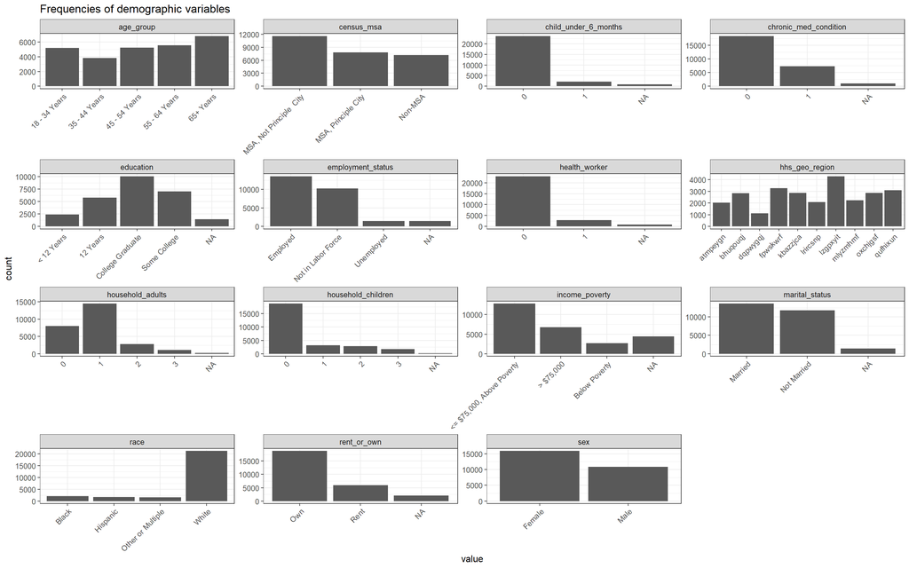

Frequencies of demographic variables

```r
# Create bar plots with frequencies of demographic variables
training %>%
  dplyr::select(age_group:household_children,health_worker,child_under_6_months,chronic_med_condition)%>%
  gather() %>%
  ggplot(aes(value)) +
    facet_wrap(~ key, scales = "free") +
    geom_bar()+
    ggtitle("Frequencies of demographic variables")+
    theme(text = element_text(size=12), axis.text.x = element_text(angle=45, hjust=1))
```

Overall, it looks like our sample maybe fairly representative of the US. However, we should be cautious about overly generalizing our models especially given the high proportion of White respondents compared non-white.

We can also look at the relationship between these demographic variables and vaccinations.

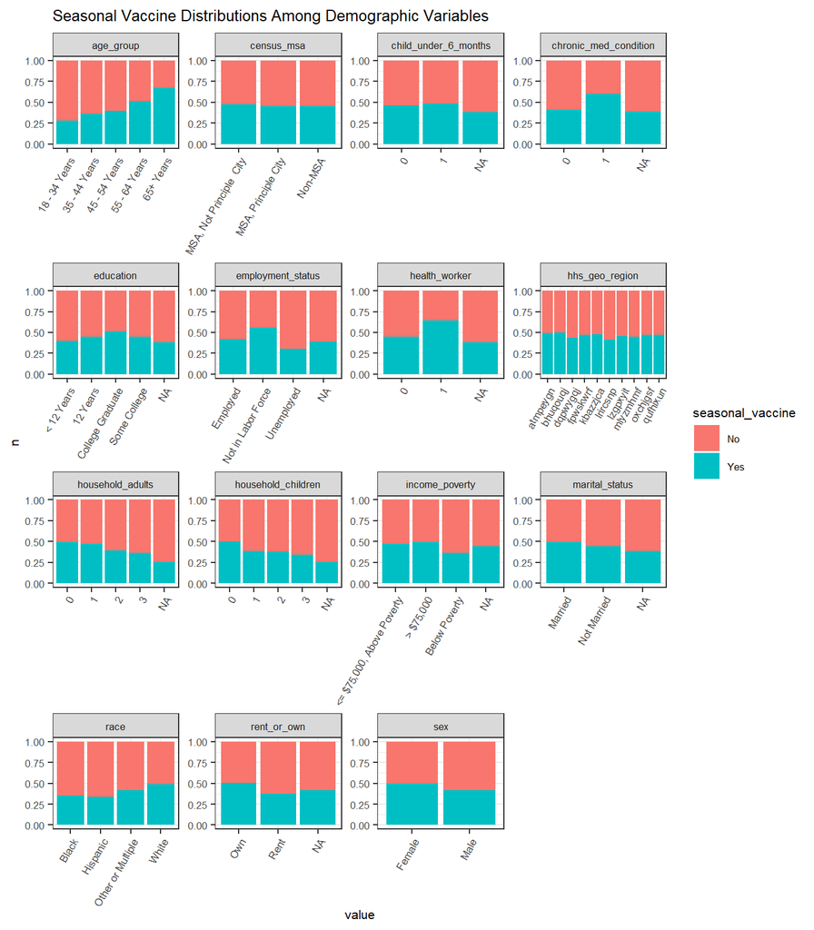

Seasonal Vaccine Distributions Among Demographic Variables

```r
# Group and tally demographic variables and seasonal flu vaccinations
seasonal_demo <-
  training %>%
  select(age_group:household_children,health_worker,child_under_6_months,chronic_med_condition,h1n1_vaccine,seasonal_vaccine) %>%
  mutate_all(as.character) %>%  # Convert them all the character so we can pivot
  mutate(seasonal_vaccine = ifelse(seasonal_vaccine == 1, 'Yes', 'No'),
         h1n1_vaccine = ifelse(h1n1_vaccine == 1, 'Yes', 'No')) %>%
  select(-h1n1_vaccine) %>%
  pivot_longer(cols = -seasonal_vaccine) %>%
  group_by(name, seasonal_vaccine, value) %>%
  tally()

# Obtain the list of names to filter during plotting
demo_names <- unique(seasonal_demo$name)

# Plots comparing seasonal flu vaccinations for different demographics
seasonal_demo %>%
  filter(name %in% demo_names[c(1:15, 9:12)]) %>%
  ggplot(aes(x = value, y = n, fill = seasonal_vaccine)) +
      facet_wrap(~ name, scales = "free") +
      geom_bar(position="fill", stat="identity")+
      ggtitle("Seasonal Vaccine Distributions Among Demographic Variables") +
      theme(text = element_text(size=8), axis.text.x = element_text(angle=60, hjust=1))
```

It looks like older people are much more likely to get flu vaccinations, which makes sense since they are the most in danger amongst the age groups we have data for. It also looks like health workers are more likely to be vaccinated than non-health workers while people with chronic health conditions are more likely to vaccinated. We can also see that unemployed respondents were less likely to get vaccines.

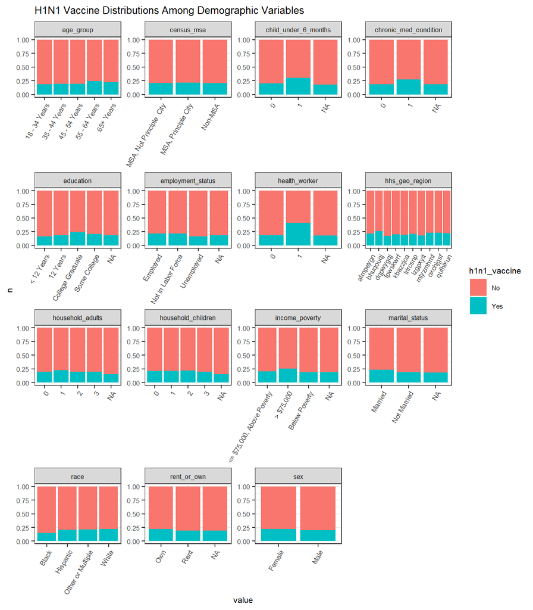

H1N1 Vaccine Distributions Among Demographic Variables

```r
# Group and tally demographic variables and h1n1 vaccinations
h1n1_demo <-
  training %>%
  select(age_group:household_children,health_worker,child_under_6_months,chronic_med_condition,h1n1_vaccine,seasonal_vaccine) %>%
  mutate_all(as.character) %>%  # Convert them all the character so we can pivot
  mutate(seasonal_vaccine = ifelse(seasonal_vaccine == 1, 'Yes', 'No'),
         h1n1_vaccine = ifelse(h1n1_vaccine == 1, 'Yes', 'No')) %>%
  select(-seasonal_vaccine) %>%
  pivot_longer(cols = -h1n1_vaccine) %>%
  group_by(name, h1n1_vaccine, value) %>%
  tally()

# Plots comparing h1n1 vaccinations for different demographics
h1n1_demo %>%
  filter(name %in% demo_names[c(1:15, 9:12)]) %>%
  ggplot(aes(x = value, y = n, fill = h1n1_vaccine)) +
      facet_wrap(~ name, scales = "free") +
      geom_bar(position="fill", stat="identity")+
      ggtitle("H1N1 Vaccine Distributions Among Demographic Variables") +
      theme(text = element_text(size=8), axis.text.x = element_text(angle=60, hjust=1))
```

From above, we can see that health workers are more likely to get h1n1 vaccinations. However, older respondents did not seem to be that much more likely than younger participants to get h1n1 vaccines. Respondents with chronic medical conditions were slightly more likely to get this vaccine.

Overall, it looks like age group and health worker could be important demographic factors in predicting vaccinations.

Next, we can look at the other potential predictors and their distributions.

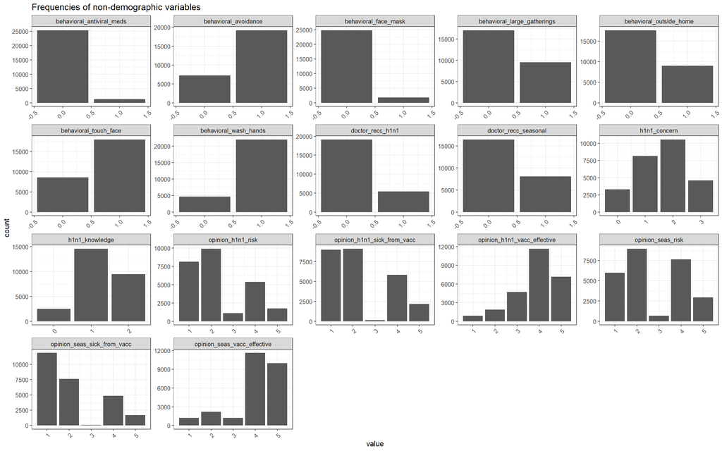

Frequencies of non-demographic variables

```r
# Create bar plots with frequencies of non-demographic variables
training %>%
  dplyr::select(h1n1_concern:opinion_seas_sick_from_vacc,-health_worker,-child_under_6_months,-chronic_med_condition)%>%
  gather() %>%
  ggplot(aes(value)) +
    facet_wrap(~ key, scales = "free") +
    geom_bar()+
    ggtitle("Frequencies of non-demographic variables")+
    theme(text = element_text(size=12), axis.text.x = element_text(angle=45, hjust=1))
```

From the frequency plots above, we can see that some of the behavioral responses like using antiviral meds and face masks have very low adherence but other behavioral responses like avoiding contacts with others, avoiding touching face and washing hands have pretty high adherence.

From the doctor recommendation variables, we can see that the respondents’ doctors were not very likely to recommend either seasonal or h1n1 vaccines. However, they were likely to recommend seasonal vaccine more than h1n1 vaccine. These rates look similar to vaccination rates for the 2 vaccines so they may be useful predictors.

It looks like participants, in general, had some knowledge about h1n1 but they were only moderately concerned. They also were more likely to consider h1n1 risk to be lower. More respondents thought the seasonal flu risks were higher than h1n1 risk.

From the opinion related plots, we see that most participants considered both seasonal and h1n1 vaccines to be effective.

Overall, almost all of these potential predictors seem to be useful in capturing some aspect of vaccination behaviors.

Let’s now look at the correlation matrix for our numeric predictors and see how they are related to each other and the vaccination rates.

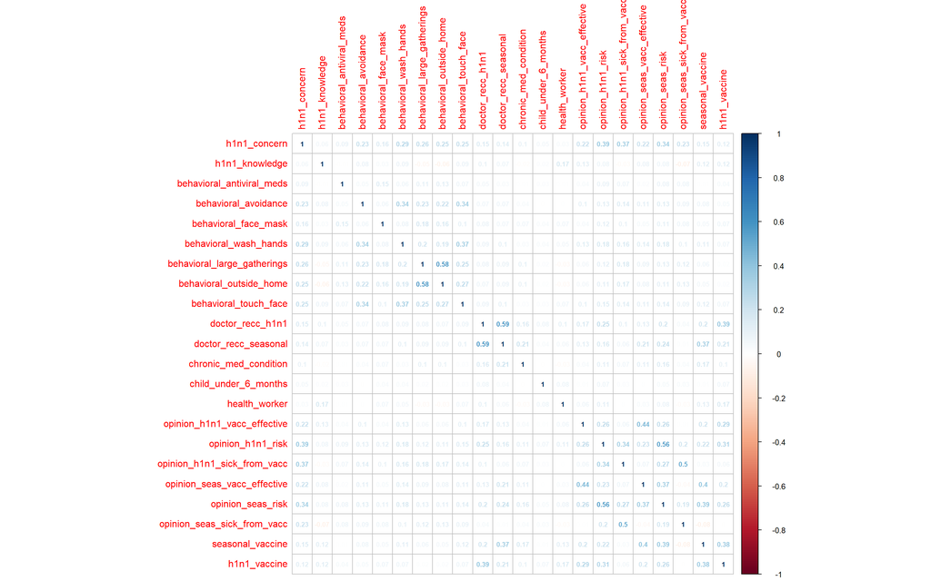

Correlation among non-demographic variables and vaccinations

```r
# Correlation plot for non-demographic predictors and vaccinations
nondemocorr <-
  training %>%
  dplyr::select(h1n1_concern:opinion_seas_sick_from_vacc, seasonal_vaccine, h1n1_vaccine) %>%
  as.matrix() %>%
  cor(method=c("spearman"), use="pairwise.complete.obs")

corrplot(nondemocorr, method="number", number.cex = .7)
```

It looks like behavioral variables seem to be positively correlated with each other. It might be possible to reduce the number of variables if we combine the behavioral variables together such that this new variable will indicate the number of safe behaviors a respondent adhered to. A `safe_behaviors` variable could just add variables from `behavioral_antiviral_meds` to `behavioral_touch_face`.

Also, `doctor_recc_h1n1` and `doctor_recc_seasonal`, which represent whether the respondent’s doctor recommended h1n1 or seasonal vaccine, also seem to be strongly positively correlated. They also seem to be somewhat correlated with the vaccination response variables. This probably supports our earlier finding that respondents who get seasonal flu vaccines are more likely to get vaccinated for h1n1 as well.

Opinion variables also seem to be correlated with each other but since they touch on different aspects of the two diseases (like risks, vaccine effectiveness, etc), it doesn’t make sense to combine them directly. We should consider including them as they are.

Below, we create the new variable combining the behavior variables. This new variable represents the total number of healthy behaviors that the respondents adhered to (in relation to flu-like diseases).

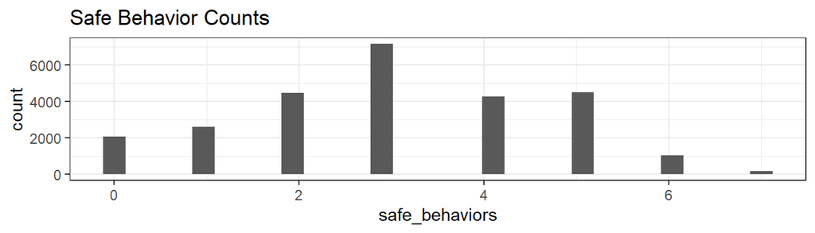

Histogram of the combined behaviors

```r
# Create new variable combining behavioral predictors
newvariable1 <- training %>%
  dplyr::select(behavioral_antiviral_meds:behavioral_touch_face) %>%
  mutate(safe_behaviors=rowSums(.,na.rm=FALSE))%>%
  dplyr::select(-behavioral_antiviral_meds:-behavioral_touch_face)

training$safe_behaviors <- newvariable1$safe_behaviors

# Remove individual behavioral variables
training <- training %>% select(-behavioral_antiviral_meds:-behavioral_touch_face)

# Frequencies of the newly created "safe_behaviors" variable
training %>%
  ggplot(aes(x=safe_behaviors))+
  geom_histogram()+
  ggtitle("Safe Behavior Counts")
```

It looks like this newly created variable is pretty normally distributed. We removed all the behavior variables and replaced it with this newly created one.

For the purposes of this project, we are evaluating multiple classification methods that we learned during the last semester. There are many instances where missing data can impact a model’s performance. This is especially an issue if there is missing data for a large chunk of observations. We already decided to not include 3 variables that had almost half missing data rate. Even without these variables, we needed to make a decision about the rest of missing data. It might be ideal to use a strong imputation method like multiple imputation to get rid of missingness. However, since this was beyond the scope of this project, we decided to simply omit missing data from our analysis. Removing the remainder missing data still resulted in a sample size of 19642 which should have enough power for our modeling purposes.

To get the dataset ready for modeling, we can split the dataset into training and test sets. We will usee this training set to train all our models and evaluate their performances on the test set. We do a 60-40 stratified split such that 60% of the overall data are in the training set while also making sure that each of the training and test set have equal representation of our 2 response variables.

```r
# Remove all remaining NAs
trainingwithoutNA = na.omit(training)

# Create training and testing sets for this project
set.seed(56)
train_index = createDataPartition(paste(trainingwithoutNA$seasonal_vaccine, trainingwithoutNA$h1n1_vaccine, sep = ""), p = 0.60, list=FALSE)
model_train = trainingwithoutNA[train_index,]
model_test =  trainingwithoutNA[-train_index,]
```

Now that we have our training and test set, we make sure our categorical variables are correctly formatted as factors.

```r
# Relevel the age_group and income poverty. Age group is already in correct order
model_train$income_poverty <-
  factor(model_train$income_poverty,
         levels = c("Below Poverty", "<= $75,000, Above Poverty", "> $75,000"))

model_train$education <-
  factor(model_train$education,
         levels = c("< 12 Years", "12 Years", "Some College", "College Graduate"))

model_train$age_group <- as.factor(model_train$age_group)

# Convert response variables to factors
model_train <- model_train %>%
  mutate(seasonal_vaccine= as_factor(seasonal_vaccine),h1n1_vaccine= as_factor(h1n1_vaccine))

# Convert character variables to factors
model_train <- model_train %>%
  mutate_if(sapply(model_train, is.character), as.factor)


# Repeat the factorization from above for the test set
model_test$income_poverty <-
  factor(model_test$income_poverty,
         levels = c("Below Poverty", "<= $75,000, Above Poverty", "> $75,000"))

model_test$education <-
  factor(model_test$education,
         levels = c("< 12 Years", "12 Years", "Some College", "College Graduate"))

model_test$age_group <- as.factor(model_test$age_group)

model_test <- model_test %>%
  mutate(seasonal_vaccine= as_factor(seasonal_vaccine),h1n1_vaccine= as_factor(h1n1_vaccine))

model_test <- model_test %>%
  mutate_if(sapply(model_test, is.character), as.factor)
```

We also divide our training set into one dataset for seasonal vaccine prediction and another dataset for h1n1 vaccine prediction.

```r
# Restrict the data so that it's directly relevant to the seasonal vaccine or the h1n1 vaccine
seasonal_train <-
  model_train %>%
  dplyr::select(-h1n1_vaccine, -respondent_id)

seasonal_test <-
  model_test %>%
  dplyr::select(-h1n1_vaccine, -respondent_id)

h1n1_train <-
  model_train %>%
  dplyr::select(-seasonal_vaccine, -respondent_id)

h1n1_test <-
  model_test %>%
  dplyr::select(-seasonal_vaccine, -respondent_id)
```

Now that our datasets are ready, we will move on to using different modeling techniques and evaluating their performances on our test set.

# Analysis

We evaluate each method’s performance, first on seasonal flu vaccine prediction and then on h1n1 vaccine prediction.

## Seasonal Flu Vaccination Classification

## Full Logistic Regression Model for Seasonal Flu

We begin by conducting a logistic regression model for seasonal vaccine. Recall that since our response is binary (either they got the vaccine or they didn’t), a logistic model would allow us to calculate the probability they got the vaccine given their specified attributes.

Given the nature of the data, as shown in the EDA, all the predictors will be used in our model (with `safe_behavior` instead of the 7 individual behavior variables). From the correlation plot, we observe that there does not appear to be any highly correlated variables, thus there is no fear of multicollinearity. Additionally, since the predictors are either nominal (male or female), ordinal (level of education), or on a scale (opinions), there is no fear of outliers. Since the sample size is large as well, we proceed onwards comfortably.

To begin, we consider all the predictors (excluding `h1n1_vaccine`) in the model for `seasonal_vaccine`. While we attempted to include interactions for `age_group` and the doctor recommendation variables, the overall test accuracy decreased, so they were not included (see appendix). Since including all pairwise interactions would have resulted in thousands of predictors, they were not considered.

Excluding the intercept, we observe a total of 44 predictors, 24 of which are significant at the 0.05 level of significance.

For predictions, we will consider the standard cutoff of 0.5. Without removing any of the model predictors, we observe the following confusion matrix for the training data:

```r
# Fit logistic reg on full data
Full_glm <-
  glm(seasonal_vaccine~., data = seasonal_train, family = binomial)

# summary(Full_glm)
# length(coef(Full_glm)) # Check the number of coefficients
```

```r
# Full GLM Model training error rates

# Get the number of rows
n_train <- nrow(seasonal_train)

# Store the predictions on the existing data
glm.probs <- predict(Full_glm, type = 'response')

# Determine predictions
glm.pred <- rep(0, n_train)
glm.pred[glm.probs > .5] <- 1

# Generate confusion matrix
table(glm.pred, seasonal_train$seasonal_vaccine)
```

```
##
## glm.pred    0    1
##        0 4991 1354
##        1 1162 4279
```

```r
# Proportion of correct responses
mean(glm.pred == seasonal_train$seasonal_vaccine)
```

```
## [1] 0.787
```

```r
# Proportion correct if you just pick 0 each time - 52%
mean(0 == seasonal_train$seasonal_vaccine)
```

```
## [1] 0.522
```

This model has a training accuracy of 78.7%, not bad! Thus, we proceed onwards to check the accuracy on new data - the testing set. Applied to the testing data, we observe the following table:

### Full logistic regression model performance on test set for seasonal flu

```r
# Get the number of rows
n_test <- nrow(seasonal_test)

# Store the predictions on the existing data
glm.probs <- predict(Full_glm, newdata = seasonal_test,type = 'response')

# Determine predictions
glm.pred <- rep(0, n_test)
glm.pred[glm.probs > .5] <- 1

# Generate confusion matrix
table(glm.pred, seasonal_test$seasonal_vaccine)
```

```
##
## glm.pred    0    1
##        0 3323  966
##        1  778 2789
```

```r
# Proportion of correct responses
mean(glm.pred == seasonal_test$seasonal_vaccine)
```

```
## [1] 0.778
```

```r
# Proportion correct if you just pick 0 each time - 52%
mean(0 == seasonal_test$seasonal_vaccine)
```

```
## [1] 0.522
```

```r
# Sensitivity
2789 / (2789 + 966)
```

```
## [1] 0.743
```

```r
# Specificity
3323 / (3323 + 778)
```

```
## [1] 0.81
```

Applied to the testing set, the accuracy dips slightly to 77.8%. While this model seems to have more false negatives than false positives, the overall accuracy seems fairly good. Nevertheless, we proceed onwards to check for a potentially more effective model.

### Lasso for Seasonal Flu

Since the full logistic regression has so many predictors, we want to explore ways to conduct variable selection. Thus, we begin with a LASSO logistic regression.

Recall that for a LASSO regression, additional variables are penalized. Thus, for variables that do not add much contribution, their coefficients are shrunk to 0.

The training confusion matrix is the following, extremely close to the logistic regression model:

```r
# Reference: http://www.sthda.com/english/articles/36-classification-methods-essentials/149-penalized-logistic-regression-essentials-in-r-ridge-lasso-and-elastic-net/

set.seed(14)

x <- model.matrix(seasonal_vaccine~., seasonal_train)[,-1]
y <- seasonal_train$seasonal_vaccine


cv.lasso <- cv.glmnet(x, y, alpha = 1, family = "binomial")

lasso_model <- glmnet(x, y, alpha = 1, family = "binomial",
                lambda = cv.lasso$lambda.min)

# coef(lasso_model)
```

```r
# Store the predictions on the existing data
lasso_train_probs <- predict(lasso_model, newx = x, type = 'response')

# Determine predictions
lasso_train_pred <- ifelse(lasso_train_probs > 0.5, 1, 0)

# Generate confusion matrix
table(lasso_train_pred, seasonal_train$seasonal_vaccine)
```

```
##
## lasso_train_pred    0    1
##                0 4992 1355
##                1 1161 4278
```

```r
mean(lasso_train_pred == seasonal_train$seasonal_vaccine)
```

```
## [1] 0.787
```

The training accuracy waas 78.7%. Now, let’s evaluate its performance on test set.

### Lasso performance on test set for seasonal flu

```r
# Make predictions on the test data
x_testing <- model.matrix(seasonal_vaccine~., seasonal_test)[,-1]
lasso_probs <- predict(lasso_model, newx = x_testing)

lasso_pred <- ifelse(lasso_probs > 0.5, 1, 0)

# Generate confusion matrix
table(lasso_pred, seasonal_test$seasonal_vaccine)
```

```
##
## lasso_pred    0    1
##          0 3614 1364
##          1  487 2391
```

```r
# Accuracy
mean(lasso_pred == seasonal_test$seasonal_vaccine)
```

```
## [1] 0.764
```

```r
# Sensitivity
2391 / (2391 + 1364)
```

```
## [1] 0.637
```

```r
# Specificity
3614 / (3614 + 487)
```

```
## [1] 0.881
```

The test accuracy is 76.4%, worse than the logistic regression model. It seems that while the training rates have remained consistent, predictions on new data have changed for the worse.

### Ridge for seasonal Flu

As a natural follow-up to the LASSO, we examine a ridge logistic regression model.

Compared to the LASSO, no variables are completely removed from the model. Instead, predictors that do not contribute much are shrunken *close* to 0.

We repeat the process with 10-fold cross validation. Here, we observe an optimal lambda value of 0.0212, so while it is still extremely close to 0, it does suggest that there may be some differences from the previous two models.

```r
set.seed(14)

cv_ridge <- cv.glmnet(x, y, alpha = 0, family = "binomial")

ridge_model <- glmnet(x, y, alpha = 0, family = "binomial",
                lambda = cv_ridge$lambda.min)

# coef(ridge_model)
```

```r
# Store the predictions on the existing data
ridge_train_probs <- predict(ridge_model, newx = x, type = 'response')

# Determine predictions
ridge_train_pred <- ifelse(ridge_train_probs > 0.5, 1, 0)

# Generate confusion matrix
table(ridge_train_pred, seasonal_train$seasonal_vaccine)
```

```
##
## ridge_train_pred    0    1
##                0 5004 1385
##                1 1149 4248
```

```r
# Accuracy
mean(ridge_train_pred == seasonal_train$seasonal_vaccine)
```

```
## [1] 0.785
```

From the training data confusion matrix, we note that this model seems to accurately predict true vaccines less than the previous models. The overall accuracy has also slightly decreased to 78.5% from 78.7%, although it definitely is a small change. The real question will be the accuracy on the testing data set.

### Ridge performance on test set for seasonal flu

```r
# Make predictions on the test data
x_testing <- model.matrix(seasonal_vaccine~., seasonal_test)[,-1]
ridge_probs <- predict(ridge_model, newx = x_testing)

ridge_pred <- ifelse(ridge_probs > 0.5, 1, 0)

# Generate confusion matrix
table(ridge_pred, seasonal_test$seasonal_vaccine)
```

```
##
## ridge_pred    0    1
##          0 3641 1440
##          1  460 2315
```

```r
# Accuracy
mean(ridge_pred == seasonal_test$seasonal_vaccine)
```

```
## [1] 0.758
```

```r
# Sensitivity
2315 / (2315 + 1440)
```

```
## [1] 0.617
```

```r
# Specificity
3641 / (3641 + 460)
```

```
## [1] 0.888
```

From the testing data confusion matrix, we can calculate the accuracy to 75.8%. This is worse than both the logistic regression and the LASSO model, so we proceed onwards.

### Quadratic Discriminant Analysis for seasonal Flu

Next, we want to consider a Quadratic Discriminant Analysis (QDA). Compared to an LDA, which would give the same results as the logistic regression, a QDA allows for unique covariance matrices and creates a quadratic relationship between the predictor and response. If there is a non-linear relationship between seasonal vaccines and the predictors, this model could provide better rates than the previous ones!

After fitting all the variables, same as the logistic regression, we observe the following confusion matrix for the training data:

```r
# Fit the QDA
qda.fit <- qda(seasonal_vaccine~., data = seasonal_train)
qda.pred <- predict(qda.fit, seasonal_train)
qda.class <- qda.pred$class
```

```r
# Confusion Matrix
table(qda.class, seasonal_train$seasonal_vaccine)
```

```
##
## qda.class    0    1
##         0 4467 1279
##         1 1686 4354
```

```r
# Accuracy
mean(qda.class == seasonal_train$seasonal_vaccine)
```

```
## [1] 0.748
```

The training accuracy is 74.8%, which is lower than all the previous models, but nevertheless we continue onwards.

Here, we have the testing confusion matrix:

### QDA performance on test set for seasonal flu

```r
# Fit the QDA
qda_test_pred <- predict(qda.fit, seasonal_test)
qda_test_class <- qda_test_pred$class

# Confusion Matrix
table(qda_test_class, seasonal_test$seasonal_vaccine)
```

```
##
## qda_test_class    0    1
##              0 2878  979
##              1 1223 2776
```

```r
# Accuracy
mean(qda_test_class == seasonal_test$seasonal_vaccine)
```

```
## [1] 0.72
```

```r
# Sensitivity
2776 / (2776 + 979)
```

```
## [1] 0.739
```

```r
# Specificity
2878 / (2878 + 1223)
```

```
## [1] 0.702
```

The testing accuracy rate has further decreased to 72%. However, we do note that this model seems to over-predict vaccinations, while the previous models under-predicted. Nevertheless, as the model seems to perform relatively poorly, we will not continue with this model.

Next, we’ll look at whether tree-based methods work better for this classification problem.

### Tree-based methods for seasonal flu

Trees are some of the most intuitive prediction methods. They are simple yet effective. They use simple decision rules to differentiate an observation into different segments based on the predictors. We can then use these decision rules to classify new data into segments and use the training observations in these segments to make predictions for the new data. In addition to using a tree to classify our response variables, we can also use other tree-based methods like bagging, random forest and boosting to create multiple trees and then combine them for improved performance.

We will evaluate each tree-based method’s performance for seasonal flu vaccination here.

### Tree for seasonal flu

Tree is the simplest tree-based method. We use all 26 potential predictors to create the tree.

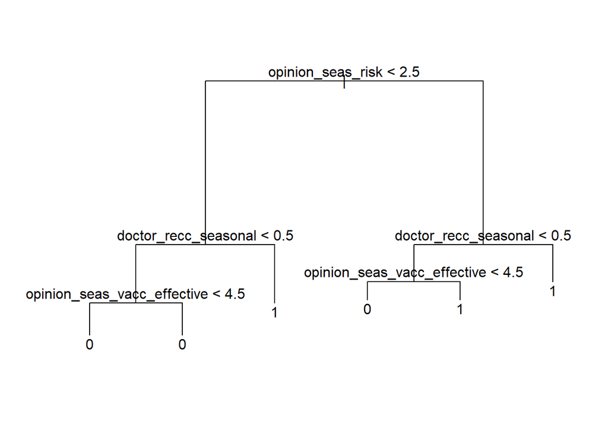

Tree predicting seasonal flu vaccination

```r
# Fit tree
tree_seasonal <- tree(seasonal_vaccine~.,seasonal_train)

plot(tree_seasonal)

text(tree_seasonal,pretty=0)
```

Above, we can see what the tree looks like. Our tree only uses 3 variables for this classification of seasonal flu vaccination: `opinion_seas_risk`, `doctor_recc_seasonal` and `opinion_seas_vacc_effective`.

We can see below how accurately this tree performs on the training set.

```r
tree.pred=predict(tree_seasonal,seasonal_train,type="class")

# Confusion matrix for the tree
table(tree.pred, seasonal_train$seasonal_vaccine)
```

```
##
## tree.pred    0    1
##         0 4726 1710
##         1 1427 3923
```

```r
# Proportion of correct predictions in training set
mean(tree.pred== seasonal_train$seasonal_vaccine)
```

```
## [1] 0.734
```

It looks like an accuracy of 73.4% is better than chance. However, an error rate of 26.6% is still not great. We can look into ways to prune this tree to see if it can lead to improved performance.

### Pruned Tree for seasonal flu

We can use cross-validation to determine what sized tree might be best for our purposes. We will use misclassification rate tog guide the cross-validation.

```r
# Prune tree
cv_tree_seasonal <-cv.tree(tree_seasonal,FUN=prune.misclass)

names(cv_tree_seasonal)
```

```
## [1] "size"   "dev"    "k"      "method"
```

```r
cv_tree_seasonal
```

```
## $size
## [1] 6 5 3 2 1
##
## $dev
## [1] 3142 3142 3291 3524 5633
##
## $k
## [1]   -Inf    0.0   74.5  238.0 2109.0
##
## $method
## [1] "misclass"
##
## attr(,"class")
## [1] "prune"         "tree.sequence"
```

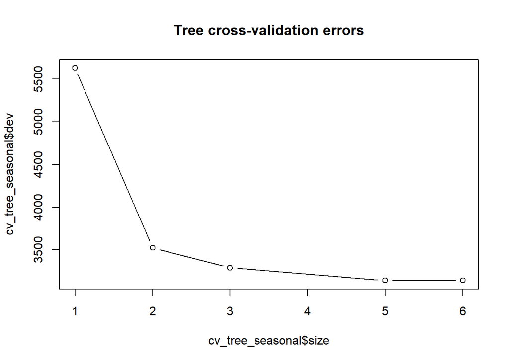

Tree cross-validation errors (Seasonal Flu)

```r
# Plot cross validation errors
plot(cv_tree_seasonal$size,cv_tree_seasonal$dev,type="b", main = "Tree cross-validation errors")
```

From the output above, it looks like cross-validation error is lowest when the tree size is 5 or 6. A tree of size 6 is the original tree we started with. So, it doesn’t seem that using size of 5 or 6 will give much different results but let’s try using a tree of size 5.

```r
prune_tree_seasonal=prune.misclass(tree_seasonal,best=5)

prunetree.pred=predict(prune_tree_seasonal,seasonal_train,type="class")

# Confusion matrix for the tree
table(prunetree.pred, seasonal_train$seasonal_vaccine)
```

```
##
## prunetree.pred    0    1
##              0 4726 1710
##              1 1427 3923
```

```r
# Proportion of correct predictions in training set
mean(prunetree.pred== seasonal_train$seasonal_vaccine)
```

```
## [1] 0.734
```

Once again, we get an accuracy of 73.4%. This suggests that pruning the above tree doesn’t really affect the performance and they lead to the exact same predictions. Therefore, let’s just look at the test set performance of the full tree.

### Tree model performance on test set for seasonal flu

```r
tree.pred.test=predict(tree_seasonal,seasonal_test,type="class")

# Confusion matrix for the tree
table(tree.pred.test, seasonal_test$seasonal_vaccine)
```

```
##
## tree.pred.test    0    1
##              0 3169 1177
##              1  932 2578
```

```r
# Proportion of correct predictions in test set
mean(tree.pred.test== seasonal_test$seasonal_vaccine)
```

```
## [1] 0.732
```

```r
# Sensitivity
2578/(2578+1177)
```

```
## [1] 0.687
```

```r
# Specificity
3169/(3169+932)
```

```
## [1] 0.773
```

The tree has test set accuracy of 73.2% (test error rate of 26.8%). It also performs worse when predicting vaccinations compared to non-vaccinations.

Based on these analysis, it doesn’t look like using a tree would be a great option. However, we can still use other techniques to combine different trees and evaluate whether these combinations are better fit for this data.

### Bagging for seasonal flu

One of the techniques to combine multiple trees is bagging. With this technique we can train a large number of trees from the same training data using bootstrapping and then combine them to create a model with reduced variance in comparison with a single tree.

```r
set.seed(56)

# Bagging for seasonal flu
bag_seasonal <- randomForest(seasonal_vaccine~.,seasonal_train, mtry=26,importance=TRUE)
bag_seasonal
```

```
##
## Call:
##  randomForest(formula = seasonal_vaccine ~ ., data = seasonal_train,      mtry = 26, importance = TRUE)
##                Type of random forest: classification
##                      Number of trees: 500
## No. of variables tried at each split: 26
##
##         OOB estimate of  error rate: 22.7%
## Confusion matrix:
##      0    1 class.error
## 0 4799 1354       0.220
## 1 1319 4314       0.234
```

### Bagged model performance on test set for seasonal flu

```r
set.seed(56)
bag.pred.test=predict(bag_seasonal,seasonal_test,type="class")

# Confusion matrix for the bagged model
table(bag.pred.test, seasonal_test$seasonal_vaccine)
```

```
##
## bag.pred.test    0    1
##             0 3245  947
##             1  856 2808
```

```r
# Proportion of correct predictions in test set
mean(bag.pred.test== seasonal_test$seasonal_vaccine)
```

```
## [1] 0.77
```

```r
# Sensitivity
2808/(2808+947)
```

```
## [1] 0.748
```

```r
# Specificity
3245/(3245+856)
```

```
## [1] 0.791
```

The bagging model has a test set accuracy of 77% (test error rate of 23%).

### Random Forest for seasonal flu

We used mtry=26 for bagging so that all available features were considered for each split of the tree. Instead of using all 26 features at each of the step, we could also only use a select few chosen randomly each time. This will ensure that a few very important features don’t get selected for every single tree causing moderately important features to be able to have an effect. This is what random forest models do.

For our random forest model, we are going to use the default mtry value, which is square root of 26 (around 5). Let’s see if that improves our performance.

```r
set.seed(56)

# Random Forest for seasonal flu
rf_seasonal <- randomForest(seasonal_vaccine~.,seasonal_train, importance=TRUE)
rf_seasonal
```

```
##
## Call:
##  randomForest(formula = seasonal_vaccine ~ ., data = seasonal_train,      importance = TRUE)
##                Type of random forest: classification
##                      Number of trees: 500
## No. of variables tried at each split: 5
##
##         OOB estimate of  error rate: 21.6%
## Confusion matrix:
##      0    1 class.error
## 0 4910 1243       0.202
## 1 1309 4324       0.232
```

Here, we can see that using random forest with 500 trees and 5 random features considered at each split results in an out of bag (OOB) error rate of 21.6% (an accuracy of 78.4%) which is better than the error rate obtained using the bagging method.

Now let’s evaluate this model’s performance on test set.

### Random Forest model performance on test set for seasonal flu

```r
set.seed(56)
rf.pred.test=predict(rf_seasonal,seasonal_test,type="class")

# Confusion matrix for the random forest
table(rf.pred.test, seasonal_test$seasonal_vaccine)
```

```
##
## rf.pred.test    0    1
##            0 3278  925
##            1  823 2830
```

```r
# Proportion of correct predictions in test set
mean(rf.pred.test== seasonal_test$seasonal_vaccine)
```

```
## [1] 0.777
```

```r
# Sensitivity
2830/(2830+925)
```

```
## [1] 0.754
```

```r
# Specificity
3278/(3278+823)
```

```
## [1] 0.799
```

The random forest model had a test set accuracy of 77.7% (a test error rate of 22.3%). It also had a pretty good accuracy for both vaccinations (0.754) and non-vaccinations (0.799).

### Boosting for seasonal flu

We can also use boosting as a method to improve performance using multiple trees. While bagging and random forest methods train multiple trees that are independent of each other, generalized boosted models grow trees sequentially, i.e. using information from the previous trees.

Here, we used a generalized boosted model with 5000 trees. Shrinkage value of 0.01 and interaction depth of 1 usually work well with most kinds of data so we are sticking with these tuning parameters for the model. A 5-fold cross-validation was also conducted to determine the optimal number of trees.

```r
set.seed(56)

# Generalized Boosted Modeling for seasonal flu
boost_seasonal <- gbm(seasonal_vaccine~.,(seasonal_train %>% mutate(seasonal_vaccine=as.integer(levels(seasonal_vaccine)[seasonal_vaccine]))), distribution = "bernoulli",n.trees=5000,interaction.depth=1,shrinkage=0.01,cv.folds=5)
boost_seasonal
```

```
## gbm(formula = seasonal_vaccine ~ ., distribution = "bernoulli",
##     data = (seasonal_train %>% mutate(seasonal_vaccine = as.integer(levels(seasonal_vaccine)[seasonal_vaccine]))),
##     n.trees = 5000, interaction.depth = 1, shrinkage = 0.01,
##     cv.folds = 5)
## A gradient boosted model with bernoulli loss function.
## 5000 iterations were performed.
## The best cross-validation iteration was 4997.
## There were 26 predictors of which 26 had non-zero influence.
```

Our cross-validation suggested that the most optimal number of trees to use for this data would be 4997.

Let’s evaluate this model’s performance on the test set.

### Boosted model performance on test set for seasonal flu

```r
set.seed(56)
boost.pred.test=predict(boost_seasonal,seasonal_test,type="response",n.trees=4997)

boost.pred.test = round(boost.pred.test)

# Confusion matrix for the boosted model
table(boost.pred.test, (seasonal_test %>% mutate(seasonal_vaccine=as.integer(levels(seasonal_vaccine)[seasonal_vaccine])))$seasonal_vaccine)
```

```
##
## boost.pred.test    0    1
##               0 3326  966
##               1  775 2789
```

```r
# Proportion of correct predictions in test set
mean(boost.pred.test== (seasonal_test %>% mutate(seasonal_vaccine=as.integer(levels(seasonal_vaccine)[seasonal_vaccine])))$seasonal_vaccine)
```

```
## [1] 0.778
```

```r
# Sensitivity
2789/(2789+966)
```

```
## [1] 0.743
```

```r
# Specificity
3326/(3326+775)
```

```
## [1] 0.811
```

Here, we see that our boosted model with 4997 trees resulted in a test set accuracy of 77.8% (test error rate of 22.2%).

Now that we have looked at multiple tree-based methods and their performances on our test set, it looks like the generalized boosted model fits the data the best when we are predicting seasonal flu vaccination. We should note that this performance was only slightly better than random forest model’s. Comparing these 2 tree-based models, the boosted model was slightly better at predicting non-vaccinations than the random forest model (81.1% for boosted vs 79.9% for random forest) whereas it was the opposite way for predicting vaccinations (74.3% for boosted model vs 75.4% for random forest model).

### Support Vector Machines for seasonal flu

Support vector machine (SVM) is an approach for classifying which does not have an assumption of linearity. The one assumption required for SVM is that the variable of interest is binary. Both variables (h1n1_vaccine and seasonal_vaccine) are binary, so the data meets this assumption. We attempted SVMs with linear, radial and polynomial kernels using default cost of 1. We were not able to tune the cost through cross-validation as the process was too computationally intensive for this project and caused more than half hour to process each. Since the default cost seemed to be working well, we stuck with it.

### SVM for Seasonal Flu (linear)

Support vector classifier (SVC) is the linear version of SVM. If the classes can be separated by a linear boundary, the SVC will have a high prediction rate.

```r
#SVC
set.seed(140)
svc.fit <- svm(seasonal_vaccine~., data=seasonal_train,kernel="linear")
summary(svc.fit)
```

```
##
## Call:
## svm(formula = seasonal_vaccine ~ ., data = seasonal_train, kernel = "linear")
##
##
## Parameters:
##    SVM-Type:  C-classification
##  SVM-Kernel:  linear
##        cost:  1
##
## Number of Support Vectors:  6072
##
##  ( 3034 3038 )
##
##
## Number of Classes:  2
##
## Levels:
##  0 1
```

```r
# Training predictions
train.pred <- predict(svc.fit, seasonal_train)

# Confusion matrix for training data
table(seasonal_train$seasonal_vaccine,train.pred)
```

```
##    train.pred
##        0    1
##   0 5015 1138
##   1 1376 4257
```

```r
# Training accuracy
mean(seasonal_train$seasonal_vaccine==train.pred)
```

```
## [1] 0.787
```

The training prediction rate for the seasonal vaccine using SVC was 78.7% (error rate 21.3%). This is comparable with models like logistic regression and random forest from above.

### SVC performance on test set for seasonal flu

```r
# Test set predictions
test.pred <- predict(svc.fit, seasonal_test)

# Confusion matrix
table(seasonal_test$seasonal_vaccine, test.pred)
```

```
##    test.pred
##        0    1
##   0 3352  749
##   1  981 2774
```

```r
# Accuracy
mean(seasonal_test$seasonal_vaccine== test.pred)
```

```
## [1] 0.78
```

```r
# Sensitivity
2774/(2774+749)
```

```
## [1] 0.787
```

```r
# Specificity
3352/(3352+981)
```

```
## [1] 0.774
```

### SVM for Seasonal Flu (radial)

A SVM with a radial kernel allows for a class to be centralized around one point (making something like a cirle), and the other class to occupy the remaining space. If the prediction rate is high for this model, then this would indicate that there is one centralized class.

```r
#SVM with radial kernel
set.seed(140)
svm.fit <- svm(seasonal_vaccine~.,data=seasonal_train, kernel="radial")
summary(svm.fit)
```

```
##
## Call:
## svm(formula = seasonal_vaccine ~ ., data = seasonal_train, kernel = "radial")
##
##
## Parameters:
##    SVM-Type:  C-classification
##  SVM-Kernel:  radial
##        cost:  1
##
## Number of Support Vectors:  6152
##
##  ( 3072 3080 )
##
##
## Number of Classes:  2
##
## Levels:
##  0 1
```

```r
# Training predictions
train.pred <-  predict(svm.fit, seasonal_train)

# Confusion matrix
table(seasonal_train$seasonal_vaccine, train.pred)
```

```
##    train.pred
##        0    1
##   0 5103 1050
##   1 1187 4446
```

```r
# Accuracy
mean(seasonal_train$seasonal_vaccine==train.pred)
```

```
## [1] 0.81
```

The training prediction rate for the radial SVM was 81% and an error rate of 19%. This looks promising!

### Radial SVM performance on test set for seasonal flu

```r
# Test set predictions
test.pred <- predict(svm.fit, seasonal_test)

# Confusion matrix
table(seasonal_test$seasonal_vaccine, test.pred)
```

```
##    test.pred
##        0    1
##   0 3326  775
##   1  929 2826
```

```r
# Accuracy
mean(seasonal_test$seasonal_vaccine== test.pred)
```

```
## [1] 0.783
```

```r
# Sensitivity
2826/(2826+775)
```

```
## [1] 0.785
```

```r
# Specificity
3326/(3326+929)
```

```
## [1] 0.782
```

### SVM for Seasonal Flu (polynomial)

SVM using a polynomial kernel is used when one class is separated completely by a second class (think of a river, with land on both sides). A high prediction rate here would indicate this kind of fit.

We fit a second degree polynomial SVM and evaluate its fit on the data.

```r
#SVM with polynomial kernel
set.seed(140)
svm.fit <- svm(seasonal_vaccine ~ ., data = seasonal_train, kernel = "poly", degree = 2)
summary(svm.fit)
```

```
##
## Call:
## svm(formula = seasonal_vaccine ~ ., data = seasonal_train, kernel = "poly",
##     degree = 2)
##
##
## Parameters:
##    SVM-Type:  C-classification
##  SVM-Kernel:  polynomial
##        cost:  1
##      degree:  2
##      coef.0:  0
##
## Number of Support Vectors:  6553
##
##  ( 3267 3286 )
##
##
## Number of Classes:  2
##
## Levels:
##  0 1
```

```r
# Training predictions
train.pred <-  predict(svm.fit, seasonal_train)

# Confusion matrix
table(seasonal_train$seasonal_vaccine, train.pred)
```

```
##    train.pred
##        0    1
##   0 5119 1034
##   1 1324 4309
```

```r
# Accuracy
mean(seasonal_train$seasonal_vaccine==train.pred)
```

```
## [1] 0.8
```

The training prediction rate was 80% (training error rate of 20%).

### Second degree polynomial SVM performance on test set for seasonal flu

```r
# Test set predictions
test.pred <- predict(svm.fit, seasonal_test)

# Confusion matrix
table(seasonal_test$seasonal_vaccine, test.pred)
```

```
##    test.pred
##        0    1
##   0 3363  738
##   1  993 2762
```

```r
# Accuracy
mean(seasonal_test$seasonal_vaccine== test.pred)
```

```
## [1] 0.78
```

```r
# Sensitivity
2762/(2762+738)
```

```
## [1] 0.789
```

```r
# Specificity
3363/(3363+993)
```

```
## [1] 0.772
```

From these models, it looks like radial SVM results in the most accurate test predictions. We evaluate the performances of all models later in the report. For now, let’s work on models to predict H1N1 flu vaccination.

## H1N1 Flu Vaccination Classification

Here we repeat the same processes for the H1N1 vaccine that we used for seasonal flu vaccine.

### Full Logistic Regression Model for H1N1

Just like the seasonal vaccine, we begin with a logistic regression model with all the predictors included. However, instead of 24 of the 44 total predictors (excluding intercept) being significant, only 19 of the predictors are significant at the .05 level for thie model.

Again using the probability of 0.5 for prediction cutoffs, we observe the following training confusion matrix:

```r
# Fit logistic reg on full data
Full_glm <-
  glm(h1n1_vaccine~., data = h1n1_train, family = binomial)

# summary(Full_glm)
```

```r
# Store the predictions on the existing data
glm.probs <- predict(Full_glm, type = 'response')

# Determine predictions
glm.pred <- rep(0, n_train)
glm.pred[glm.probs > .5] <- 1

# Generate confusion matrix
table(glm.pred, h1n1_train$h1n1_vaccine)
```

```
##
## glm.pred    0    1
##        0 8532 1455
##        1  545 1254
```

```r
# Proportion of correct responses
mean(glm.pred == h1n1_train$h1n1_vaccine)
```

```
## [1] 0.83
```

```r
# Proportion correct if you just pick 0 each time - 77%
mean(0 == h1n1_train$h1n1_vaccine)
```

```
## [1] 0.77
```

This model has a training accuracy of 83%, better than the seasonal vaccine rates! However, we do note that generally speaking, there are far more observations in this set that did not get vaccinated. Even the naive model has an accuracy rate of 77% here. Thus, we proceed onwards to the testing confusion matrix below:

### Full logistic regression performance on test set for h1n1 flu

```r
# Store the predictions on the existing data
glm.probs <- predict(Full_glm, newdata = h1n1_test,type = 'response')

# Determine predictions
glm.pred <- rep(0, n_test)
glm.pred[glm.probs > .5] <- 1

# Generate confusion matrix
table(glm.pred, h1n1_test$h1n1_vaccine)
```

```
##
## glm.pred    0    1
##        0 5664  943
##        1  387  862
```

```r
# Proportion of correct responses
mean(glm.pred == h1n1_test$h1n1_vaccine)
```

```
## [1] 0.831
```

```r
# Proportion correct if you just pick 0 each time - 52%
mean(0 == h1n1_test$h1n1_vaccine)
```

```
## [1] 0.77
```

```r
# Sensitivity
862 / (862 + 943)
```

```
## [1] 0.478
```

```r
# specificity
5664 / (5664 + 387)
```

```
## [1] 0.936
```

Applied to the testing set, the accuracy increases slightly to 83.1%. This seems to be a pretty good result, as the naive model has a 77% accuracy rate. However, as noted before, this model does include more insignificant variables. In fact, our prediction accuracy for vaccinations is just 47.8%. We proceed onwards to the lasso and ridge models to see if there will be any variable selection.

## Lasso for H1N1

Just like before, we will begin with 10-fold cross validation to determine the optimal lambda. We note that as the optimal value is 0.000909, also close to the normal logistic regression (lambda = 0).

However, unlike the LASSO for seasonal vaccine, 6 predictors are removed from this model. This includes two variables for region (kbazzjca and lrircsnp), the medium level income (income_poverty<= $75,000, Above Poverty), those who have 12 years of school or some college, and those aged between 35 - 44 Years.

The training confusion matrix becomes the following:

```r
set.seed(14)

x <- model.matrix(h1n1_vaccine~., h1n1_train)[,-1]
y <- h1n1_train$h1n1_vaccine


cv.lasso <- cv.glmnet(x, y, alpha = 1, family = "binomial")

lasso_model <- glmnet(x, y, alpha = 1, family = "binomial",
                lambda = cv.lasso$lambda.min)

# coef(lasso_model)
```

```r
# Store the predictions on the existing data
lasso_train_probs <- predict(lasso_model, newx = x, type = 'response')

# Determine predictions
lasso_train_pred <- ifelse(lasso_train_probs > 0.5, 1, 0)

# Generate confusion matrix
table(lasso_train_pred, h1n1_train$h1n1_vaccine)
```

```
##
## lasso_train_pred    0    1
##                0 8539 1481
##                1  538 1228
```

```r
# Accuracy
mean(lasso_train_pred == h1n1_train$h1n1_vaccine)
```

```
## [1] 0.829
```

The training accuracy is 82.9%, a slight decrease compared to the logistic regression model.

### Lasso performance on test set for h1n1 flu

```r
# Make predictions on the test data
x_testing <- model.matrix(h1n1_vaccine~., h1n1_test)[,-1]
lasso_probs <- predict(lasso_model, newx = x_testing)

lasso_pred <- ifelse(lasso_probs > 0.5, 1, 0)

# Generate confusion matrix
table(lasso_pred, h1n1_test$h1n1_vaccine)
```

```
##
## lasso_pred    0    1
##          0 5846 1201
##          1  205  604
```

```r
# Accuracy
mean(lasso_pred == h1n1_test$h1n1_vaccine)
```

```
## [1] 0.821
```

```r
# Sensitivity
604 / (604 + 1201)
```

```
## [1] 0.335
```

```r
# Specificity
5846 / (5846 + 205)
```

```
## [1] 0.966
```

The testing accuracy is 82.1%, also lower than the logistic regression.

## Ridge for H1N1

Continuing onwards to the ridge logistic regression, the 10-fold cross validation suggests that the optimal lambda value is 0.0166.

```r
set.seed(14)

cv_ridge <- cv.glmnet(x, y, alpha = 0, family = "binomial")

ridge_model <- glmnet(x, y, alpha = 0, family = "binomial",
                lambda = cv_ridge$lambda.min)

# coef(ridge_model)
```

```r
# Store the predictions on the existing data
ridge_train_probs <- predict(ridge_model, newx = x, type = 'response')

# Determine predictions
ridge_train_pred <- ifelse(ridge_train_probs > 0.5, 1, 0)

# Generate confusion matrix
table(ridge_train_pred, h1n1_train$h1n1_vaccine)
```

```
##
## ridge_train_pred    0    1
##                0 8587 1535
##                1  490 1174
```

```r
# Accuracy
mean(ridge_train_pred == h1n1_train$h1n1_vaccine)
```

```
## [1] 0.828
```

From the training data confusion matrix, we note that the accuracy is about the same as the LASSO, a rate of about 82.8%.

### Ridge performance on test set for h1n1 flu

```r
# Make predictions on the test data
x_testing <- model.matrix(h1n1_vaccine~., h1n1_test)[,-1]
ridge_probs <- predict(ridge_model, newx = x_testing)

ridge_pred <- ifelse(ridge_probs > 0.5, 1, 0)

# Generate confusion matrix
table(ridge_pred, h1n1_test$h1n1_vaccine)
```

```
##
## ridge_pred    0    1
##          0 5872 1258
##          1  179  547
```

```r
# Accuracy
mean(ridge_pred == h1n1_test$h1n1_vaccine)
```

```
## [1] 0.817
```

```r
# Sensitivity
547 / (547 + 1258)
```

```
## [1] 0.303
```

```r
# Specificity
5872 / (5872 + 179)
```

```
## [1] 0.97
```

From the testing data confusion matrix, we can calculate the accuracy to be 81.7%. Again, it exhibits the same pattern as the seasonal vaccine, where ridge has again performed the worse compared to the logistic regression and the LASSO.

## QDA for H1N1

Next, we want to consider QDA for a potential quadratic relationship with `h1n1_vaccine`.

After fitting all the variables, same as the logistic regression, we observe the following confusion matrix for the training data:

```r
# Fit the QDA
qda.fit <- qda(h1n1_vaccine~., data = h1n1_train)
qda.pred <- predict(qda.fit, h1n1_train)
qda.class <- qda.pred$class
```

```r
# Confusion Matrix
table(qda.class, h1n1_train$h1n1_vaccine)
```

```
##
## qda.class    0    1
##         0 7591  938
##         1 1486 1771
```

```r
# Accuracy
mean(qda.class == h1n1_train$h1n1_vaccine)
```

```
## [1] 0.794
```

The training accuracy is 79.4%, which is again lower than all the previous models.

Here, we have the testing confusion matrix:

### QDA performance on test set for h1n1 flu

```r
# Fit the QDA
qda_test_pred <- predict(qda.fit, h1n1_test)
qda_test_class <- qda_test_pred$class

# Confusion Matrix
table(qda_test_class, h1n1_test$h1n1_vaccine)
```

```
##
## qda_test_class    0    1
##              0 5016  697
##              1 1035 1108
```

```r
# Accuracy
mean(qda_test_class == h1n1_test$h1n1_vaccine)
```

```
## [1] 0.78
```

```r
# Sensitivity
1108 / (1108 + 697)
```

```
## [1] 0.614
```

```r
# Specificity
5016 / (5016 + 1035)
```

```
## [1] 0.829
```

The testing accuracy rate has further decreased to 78%. It would appear that just like the seasonal vaccine, the three linear approaches used previously fit the data much better. Although we should note that this model is more sensitive but less specific than the previous models.

Now, just like before, we will see whether the tree-based methods result in better predictions.

### Tree-based methods for H1N1

### Tree for h1n1

Here, we create a simple tree for h1n1 vaccination classification.

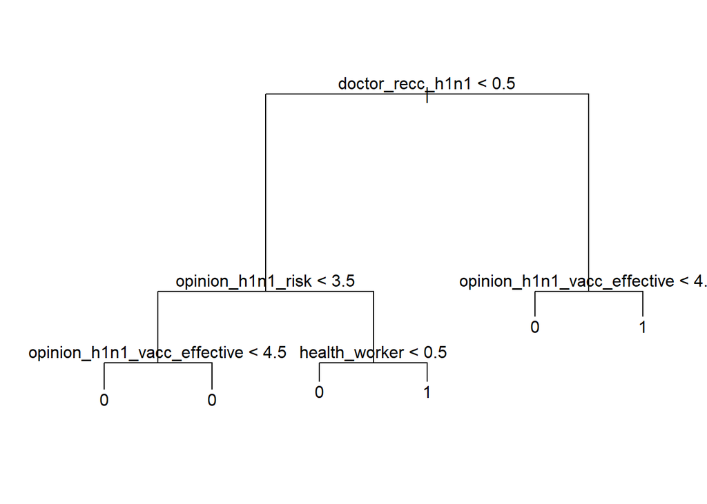

Tree for h1n1 vaccine prediction

```r
# Fit tree
tree_h1n1 <- tree(h1n1_vaccine~.,h1n1_train)

plot(tree_h1n1)

text(tree_h1n1,pretty=0)
```

Above, we can see what the tree looks like. Our tree only uses 4 variables for this classification: `opinion_h1n1_risk`, `doctor_recc_h1n1`, `opinion_h1n1_vacc_effective`, and `health_worker`.

We can see below how accurately this tree performs on the training set.

```r
tree.pred=predict(tree_h1n1,h1n1_train,type="class")

# Confusion matrix for the tree
table(tree.pred, h1n1_train$h1n1_vaccine)
```

```
##
## tree.pred    0    1
##         0 8621 1730
##         1  456  979
```

```r
# Proportion of correct predictions in training set
mean(tree.pred== h1n1_train$h1n1_vaccine)
```

```
## [1] 0.815
```

It looks like we get an accuracy of 81.5% (an error rate of 18.5%), which is pretty good. Let’s see if pruning this tree can lead to improved performance.

### Pruned Tree for h1n1

Just like before, we use misclassification rate to guide the cross-validation to determine the optimal size of the pruned tree.

```r
# Prune tree
cv_tree_h1n1 <-cv.tree(tree_h1n1,FUN=prune.misclass)

names(cv_tree_h1n1)
```

```
## [1] "size"   "dev"    "k"      "method"
```

```r
cv_tree_h1n1
```

```
## $size
## [1] 6 5 3 1
##
## $dev
## [1] 2186 2186 2269 2709
##
## $k
## [1] -Inf    0   40  222
##
## $method
## [1] "misclass"
##
## attr(,"class")
## [1] "prune"         "tree.sequence"
```

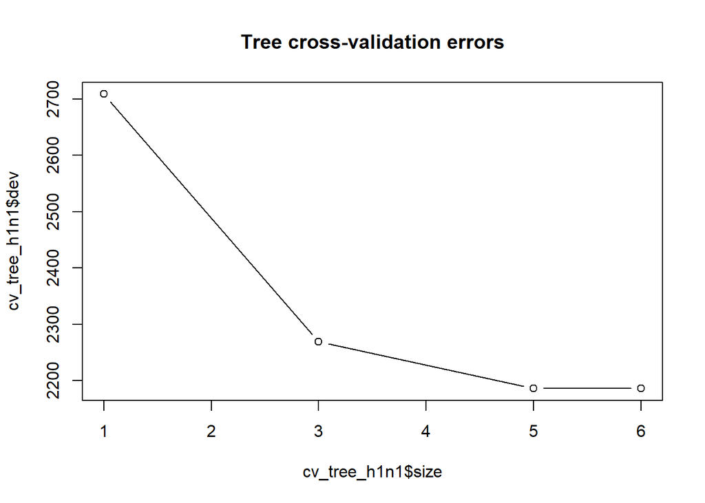

Tree cross-validation errors (H1N1)

```r
# Plot cross validation errors
plot(cv_tree_h1n1$size,cv_tree_h1n1$dev,type="b", main="Tree cross-validation errors")
```

From the output above, it looks like cross-validation error is lowest when the tree size is 5 or 6. A tree of size 6 is the original tree we started with so, let’s just try using a tree of size 5.

```r
prune_tree_h1n1=prune.misclass(tree_h1n1,best=5)

prunetree.pred=predict(prune_tree_h1n1,h1n1_train,type="class")

# Confusion matrix for the tree
table(prunetree.pred, h1n1_train$h1n1_vaccine)
```

```
##
## prunetree.pred    0    1
##              0 8621 1730
##              1  456  979
```

```r
# Proportion of correct predictions in training set
mean(prunetree.pred== h1n1_train$h1n1_vaccine)
```

```
## [1] 0.815
```

Once again, we get an accuracy of 81.5%. This suggests that pruning the above tree doesn’t really affect the performance and they lead to the exact same predictions. Therefore, we just look at the test set performance of the full tree.

### Tree model performance on test set for h1n1

```r
tree.pred.test.h1n1=predict(tree_h1n1,h1n1_test,type="class")

# Confusion matrix for the tree
table(tree.pred.test.h1n1, h1n1_test$h1n1_vaccine)
```

```
##
## tree.pred.test.h1n1    0    1
##                   0 5722 1131
##                   1  329  674
```

```r
# Proportion of correct predictions in training set
mean(tree.pred.test.h1n1== h1n1_test$h1n1_vaccine)
```

```
## [1] 0.814
```

```r
# Sensitivity
674 / (674 + 1131)
```

```
## [1] 0.373
```

```r
# specificity
5722 / (5722 + 329)
```

```
## [1] 0.946
```

The tree has test set accuracy of 81.4% (test error rate of 18.6%). It predicts vaccinations accurately 37.3% of the time, which is worse than the full logistic regression model.

Next we attempt bagging trees.

### Bagging for h1n1

```r
set.seed(56)

# Bagging for h1n1
bag_h1n1 <- randomForest(h1n1_vaccine~.,h1n1_train, mtry=26,importance=TRUE)
bag_h1n1
```

```
##
## Call:
##  randomForest(formula = h1n1_vaccine ~ ., data = h1n1_train, mtry = 26,      importance = TRUE)
##                Type of random forest: classification
##                      Number of trees: 500
## No. of variables tried at each split: 26
##
##         OOB estimate of  error rate: 17.5%
## Confusion matrix:
##      0    1 class.error
## 0 8452  625      0.0689
## 1 1434 1275      0.5293
```

We can see that bagging results in an out of bag (OOB) error rate of just 17.5% (accuracy of 82.5%), which is better than 18.5% training error rate we got for the pruned and unpruned trees.

### Bagged model performance on test set for h1n1

```r
set.seed(56)
bag.pred.test.h1n1=predict(bag_h1n1,h1n1_test,type="class")

# Confusion matrix for the bagged model
table(bag.pred.test.h1n1, h1n1_test$h1n1_vaccine)
```

```
##
## bag.pred.test.h1n1    0    1
##                  0 5629  949
##                  1  422  856
```

```r
# Proportion of correct predictions in training set
mean(bag.pred.test.h1n1== h1n1_test$h1n1_vaccine)
```

```
## [1] 0.825
```

```r
# Sensitivity
856 / (856 + 949)
```

```
## [1] 0.474
```

```r
# specificity
5629 / (5629 + 422)
```

```
## [1] 0.93
```

The bagging model has a test set accuracy of 82.5% (test error rate of 17.5%). This model predicts h1n1 vaccinations with accuracy of 47.4% while non-vaccinations have an accuracy of 93%.

### Random Forest for h1n1

```r
set.seed(56)

# Random Forest for h1n1
rf_h1n1 <- randomForest(h1n1_vaccine~.,h1n1_train, importance=TRUE)
rf_h1n1
```

```
##
## Call:
##  randomForest(formula = h1n1_vaccine ~ ., data = h1n1_train, importance = TRUE)
##                Type of random forest: classification
##                      Number of trees: 500
## No. of variables tried at each split: 5
##
##         OOB estimate of  error rate: 17.2%
## Confusion matrix:
##      0    1 class.error
## 0 8551  526      0.0579
## 1 1507 1202      0.5563
```

Here, we can see that using random forest with 500 trees and 5 random features considered at each split results in an out of bag (OOB) error rate of 17.2% (an accuracy of 82.8%) which is slightly better than the error rate obtained using the bagging method.

Now let’s evaluate this model’s performance on test set.

### Random Forest model performance on test set for h1n1

```r
set.seed(56)
rf.pred.test.h1n1=predict(rf_h1n1,h1n1_test,type="class")

# Confusion matrix for the random forest
table(rf.pred.test.h1n1, h1n1_test$h1n1_vaccine)
```

```
##
## rf.pred.test.h1n1    0    1
##                 0 5694  980
##                 1  357  825
```

```r
# Proportion of correct predictions in training set
mean(rf.pred.test.h1n1== h1n1_test$h1n1_vaccine)
```

```
## [1] 0.83
```

```r
# Sensitivity
825 / (825 + 980)
```

```
## [1] 0.457
```

```r
# specificity
5694 / (5694 + 357)
```

```
## [1] 0.941
```

The random forest model had a test set accuracy of 83% (a test error rate of 17%).

### Boosting for h1n1

We can also use boosting and evaluate its performance. A 5-fold cross-validation was also conducted to determine the optimal number of trees.

```r
set.seed(56)

# Boosting for h1n1
boost_h1n1 <- gbm(h1n1_vaccine~.,(h1n1_train %>% mutate(h1n1_vaccine=as.integer(levels(h1n1_vaccine)[h1n1_vaccine]))), distribution = "bernoulli",n.trees=5000,interaction.depth=1,shrinkage=0.01,cv.folds=5)
boost_h1n1
```

```
## gbm(formula = h1n1_vaccine ~ ., distribution = "bernoulli", data = (h1n1_train %>%
##     mutate(h1n1_vaccine = as.integer(levels(h1n1_vaccine)[h1n1_vaccine]))),
##     n.trees = 5000, interaction.depth = 1, shrinkage = 0.01,
##     cv.folds = 5)
## A gradient boosted model with bernoulli loss function.
## 5000 iterations were performed.
## The best cross-validation iteration was 3911.
## There were 26 predictors of which 26 had non-zero influence.
```

Our cross-validation suggested that the most optimal number of trees to use for this data would be 3911.

Let’s evaluate this models performance on the test set.

### Boosted model performance on test set for h1n1

```r
set.seed(56)
boost.pred.test.h1n1=predict(boost_h1n1,h1n1_test,type="response",n.trees=3911)

boost.pred.test.h1n1 = round(boost.pred.test.h1n1)

# Confusion matrix for the boosted model
table(boost.pred.test.h1n1, (h1n1_test %>% mutate(h1n1_vaccine=as.integer(levels(h1n1_vaccine)[h1n1_vaccine])))$h1n1_vaccine)
```

```
##
## boost.pred.test.h1n1    0    1
##                    0 5663  950
##                    1  388  855
```

```r
# Proportion of correct predictions in training set
mean(boost.pred.test.h1n1== (h1n1_test %>% mutate(h1n1_vaccine=as.integer(levels(h1n1_vaccine)[h1n1_vaccine])))$h1n1_vaccine)
```

```
## [1] 0.83
```

```r
# Sensitivity
855 / (855 + 950)
```

```
## [1] 0.474
```

```r
# specificity
5663 / (5663 + 388)
```

```
## [1] 0.936
```

Here, we see that our boosted model with 3911 trees resulted in a test set accuracy of 83% (test error rate of 17%).

Overall, it looks like the random forest and the boosted models were the best performing tree-based model with regards to h1n1 vaccination prediction.

### SVM for H1N1

### SVM for H1N1 Flu (linear)

Here, we use a linear SVM.

```r
#SVC
set.seed(140)
svc.fit <- svm(h1n1_vaccine~., data=h1n1_train,kernel="linear")
summary(svc.fit)
```

```
##
## Call:
## svm(formula = h1n1_vaccine ~ ., data = h1n1_train, kernel = "linear")
##
##
## Parameters:
##    SVM-Type:  C-classification
##  SVM-Kernel:  linear
##        cost:  1
##
## Number of Support Vectors:  4756
##
##  ( 2386 2370 )
##
##
## Number of Classes:  2
##
## Levels:
##  0 1
```

```r
# Training predictions
train.pred <- predict(svc.fit, h1n1_train)

# Confusion matrix for training data
table(h1n1_train$h1n1_vaccine,train.pred)
```

```
##    train.pred
##        0    1
##   0 8486  591
##   1 1410 1299
```

```r
# Training accuracy
mean(h1n1_train$h1n1_vaccine==train.pred)
```

```
## [1] 0.83
```

The training prediction rate for the h1n1 vaccine using SVC was 83% (error rate 17%).

### SVC performance on test set for h1n1 flu

```r
# Test set predictions
test.pred <- predict(svc.fit, h1n1_test)

# Confusion matrix
table(h1n1_test$h1n1_vaccine, test.pred)
```

```
##    test.pred
##        0    1
##   0 5637  414
##   1  937  868
```

```r
# Accuracy
mean(h1n1_test$h1n1_vaccine== test.pred)
```

```
## [1] 0.828
```

```r
# Sensitivity
868/(868+414)
```

```
## [1] 0.677
```

```r
# Specificity
5637/(5637+937)
```

```
## [1] 0.857
```

### SVM for h1n1 Flu (radial)

Here we fit a radial SVM for h1n1 vaccine.

```r
#SVM with radial kernel
set.seed(140)
svm.fit <- svm(h1n1_vaccine~.,data=h1n1_train, kernel="radial")
summary(svm.fit)
```

```
##
## Call:
## svm(formula = h1n1_vaccine ~ ., data = h1n1_train, kernel = "radial")
##
##
## Parameters:
##    SVM-Type:  C-classification
##  SVM-Kernel:  radial
##        cost:  1
##
## Number of Support Vectors:  4874
##
##  ( 2624 2250 )
##
##
## Number of Classes:  2
##
## Levels:
##  0 1
```

```r
# Training predictions
train.pred <-  predict(svm.fit, h1n1_train)

# Confusion matrix
table(h1n1_train$h1n1_vaccine, train.pred)
```

```
##    train.pred
##        0    1
##   0 8618  459
##   1 1407 1302
```

```r
# Accuracy
mean(h1n1_train$h1n1_vaccine==train.pred)
```

```
## [1] 0.842
```

The training prediction rate for the radial SVM was 84.2% and an error rate of 15.8%.

### Radial SVM performance on test set for h1n1 flu

```r
# Test set predictions
test.pred <- predict(svm.fit, h1n1_test)

# Confusion matrix
table(h1n1_test$h1n1_vaccine, test.pred)
```

```
##    test.pred
##        0    1
##   0 5689  362
##   1  989  816
```

```r
# Accuracy
mean(h1n1_test$h1n1_vaccine== test.pred)
```

```
## [1] 0.828
```

```r
# Sensitivity
816/(816+362)
```

```
## [1] 0.693
```

```r
# Specificity
5689/(5689+989)
```

```
## [1] 0.852
```

### SVM for h1n1 Flu (polynomial)

We fit a second degree polynomial SVM and evaluate its fit on the data.

```r
#SVM with polynomial kernel
set.seed(140)
svm.fit <- svm(h1n1_vaccine ~ ., data = h1n1_train, kernel = "poly", degree = 2)
summary(svm.fit)
```

```
##
## Call:
## svm(formula = h1n1_vaccine ~ ., data = h1n1_train, kernel = "poly",
##     degree = 2)
##
##
## Parameters:
##    SVM-Type:  C-classification
##  SVM-Kernel:  polynomial
##        cost:  1
##      degree:  2
##      coef.0:  0
##
## Number of Support Vectors:  4696
##
##  ( 2433 2263 )
##
##
## Number of Classes:  2
##
## Levels:
##  0 1
```

```r
# Training predictions
train.pred <-  predict(svm.fit, h1n1_train)

# Confusion matrix
table(h1n1_train$h1n1_vaccine, train.pred)
```

```
##    train.pred
##        0    1
##   0 8608  469
##   1 1478 1231
```

```r
# Accuracy
mean(h1n1_train$h1n1_vaccine==train.pred)
```

```
## [1] 0.835
```

The training prediction rate was 83.5% (training error rate of 16.5%).

### Second degree polynomial SVM performance on test set for h1n1 flu

```r
# Test set predictions
test.pred <- predict(svm.fit, h1n1_test)

# Confusion matrix
table(h1n1_test$h1n1_vaccine, test.pred)
```

```
##    test.pred
##        0    1
##   0 5705  346
##   1 1000  805
```

```r
# Accuracy
mean(h1n1_test$h1n1_vaccine== test.pred)
```

```
## [1] 0.829
```

```r
# Sensitivity
805/(805+346)
```

```
## [1] 0.699
```

```r
# Specificity
5705/(5705+1000)
```

```
## [1] 0.851
```

## Comparing all models

### Seasonal Flu Vaccination Models

Below, we see the test set results for each model that was used to predict test set seasonal flu vaccinations.

```r
seasonalflu_results_table <- data.frame(Methods = c("Full logistic regression","Lasso","Ridge","QDA","Tree","Bagged trees","Random Forest","Generalized Boosted Model","Support Vector Classifier","Radial SVM","Polynomial SVM"))

seasonalflu_results_table <- seasonalflu_results_table %>% mutate("Overall Accuracy"=c(0.778,0.764,0.758,0.72,0.732,0.77,0.777,0.778,0.78,0.783,0.78),"Sensitivity"=c(0.743,0.637,0.617,0.739,0.687,0.748,0.754,0.743,0.787,0.785,0.789),"Specificity"=c(0.81,0.881,0.888,0.702,0.773,0.791,0.799,0.811,0.774,0.782,0.772))

kable(seasonalflu_results_table %>% arrange(desc(`Overall Accuracy`)))
```

| Methods | Overall Accuracy | Sensitivity | Specificity |
| --- | --- | --- | --- |
| Radial SVM | 0.783 | 0.785 | 0.782 |
| Support Vector Classifier | 0.780 | 0.787 | 0.774 |
| Polynomial SVM | 0.780 | 0.789 | 0.772 |
| Full logistic regression | 0.778 | 0.743 | 0.810 |
| Generalized Boosted Model | 0.778 | 0.743 | 0.811 |
| Random Forest | 0.777 | 0.754 | 0.799 |
| Bagged trees | 0.770 | 0.748 | 0.791 |
| Lasso | 0.764 | 0.637 | 0.881 |
| Ridge | 0.758 | 0.617 | 0.888 |
| Tree | 0.732 | 0.687 | 0.773 |
| QDA | 0.720 | 0.739 | 0.702 |

From the table above, we can see that the radial support vector machine model that we created was the most accurate overall. In general the SVM methods seem to have outperformed all other methods. However, we should note that the performances of the full logistic regression, generalized boosted model and the random forest model were not that far behind. The SVM methods had the best overall accuracy but they were also much better at predicting vaccinations as we can see from their high sensitivity. However, their specificity were slightly lower than that of the logistic, random forest and GBM.

Since our goal for this project is to create a model to predict how likely respondents were to vaccinate, it seems that radial SVM would be the best choice with regards to seasonal flu vaccination. It had the best overall accuracy but also had a pretty high sensitivity.

### H1N1 Vaccination Models

Next, let’s compare the test results for each model that was used to predict test set h1n1 vaccinations.

```r
h1n1flu_results_table <- data.frame(Methods = c("Full logistic regression","Lasso","Ridge","QDA","Tree","Bagged trees","Random Forest","Generalized Boosted Model","Support Vector Classifier","Radial SVM","Polynomial SVM"))

h1n1flu_results_table <- h1n1flu_results_table %>% mutate("Overall Accuracy"=c(0.831,0.821,0.817,0.78,0.814,0.825,0.83,0.83,0.828,0.828,0.829),"Sensitivity"=c(0.478,0.335,0.303,0.614,0.373,0.474,0.457,0.474,0.677,0.693,0.699),"Specificity"=c(0.936,0.966,0.97,0.829,0.946,0.93,0.941,0.936,0.857,0.852,0.851))

kable(h1n1flu_results_table %>% arrange(desc(`Overall Accuracy`)))
```

| Methods | Overall Accuracy | Sensitivity | Specificity |
| --- | --- | --- | --- |
| Full logistic regression | 0.831 | 0.478 | 0.936 |
| Random Forest | 0.830 | 0.457 | 0.941 |
| Generalized Boosted Model | 0.830 | 0.474 | 0.936 |
| Polynomial SVM | 0.829 | 0.699 | 0.851 |
| Support Vector Classifier | 0.828 | 0.677 | 0.857 |
| Radial SVM | 0.828 | 0.693 | 0.852 |
| Bagged trees | 0.825 | 0.474 | 0.930 |
| Lasso | 0.821 | 0.335 | 0.966 |
| Ridge | 0.817 | 0.303 | 0.970 |
| Tree | 0.814 | 0.373 | 0.946 |
| QDA | 0.780 | 0.614 | 0.829 |

From this table, we can see that the full logistic regression, random forest and generalized boosted models gave the best overall results. However, the SVM methods were not far behind. We should note the sensitivity scores of the SVM methods are much higher than that of other methods. So, even though logistic regression, random forest and GBM seem to have slightly higher overall accuracy, their low sensitivity scores might lead to more false negatives.

# Conclusions

Based on the analysis presented in this report, it looks like if we are interested in predicting seasonal and h1n1 flu vaccinations, support vector machines might be our best choice for methods. While radial SVM had the best overall performance for seasonal flu vaccinations, second-degree polynomial SVM had better h1n1 flu vaccinations among the SVM methods. These methods had great overall accuracy and sensitivity for both response variables. Since the goal of the contest we were evaluating these models for was to predict how likely respondents were to get vaccinated, it might make sense to put slightly greater weight to sensitivity than specificity.

Since we identified Support Vector Machines as the best methods for this problem, we should discuss a limitation with these methods for the current project. We used the default cost parameter for our SVM models and they produced excellent results. It’s possible that by tuning the cost parameter, we might be able to improve upon the performances. Our attempts to use cross-validation to tune this parameter was thwarted by our computational limits. If we decide to make official submission to the contest, we will look into ways to utilize Penn State’s cluster computing services to perform this tuning in a timely manner.

From our analysis for this project, we were also able to identify several predictors that seemed to be much more important in predicting vaccination rates. The random forest and generalized boosted models, that performed pretty well on both seasonal and h1n1 flu vaccines, suggested that the respondents’ opinions on the risk of the disease, on the effectiveness of the vaccine, and their doctor’s recommendations were the most important predictors along with age group (see appendix). From these observations, if our goal is to increase vaccination rates, it seems like we should design interventions to increase people’s’ awareness of the risks and vaccine effectiveness. We should also try to get more medical professionals to recommend vaccinations directly to their patients. By intervening on these factors, we might be able to increase vaccination rates.

We are currently in the middle of a global pandemic of COVID-19 that has infected millions of people worldwide. Based on our models for both seasonal flu and h1n1 vaccines, it seems likely that COVID-19 vaccination rates will also be affected by these factors. Even though we don’t have a vaccine for it yet, its a good idea to plan for interventions that will increase the COVID-19 vaccination rates.

Overall, our analysis provides a great stepping stone to determining how we can improve vaccination rates and thus protect the general population from contagious virus diseases.

# Appendix

## Data source

https://www.drivendata.org/competitions/66/flu-shot-learning/

## Important predictors according to tree-based methods

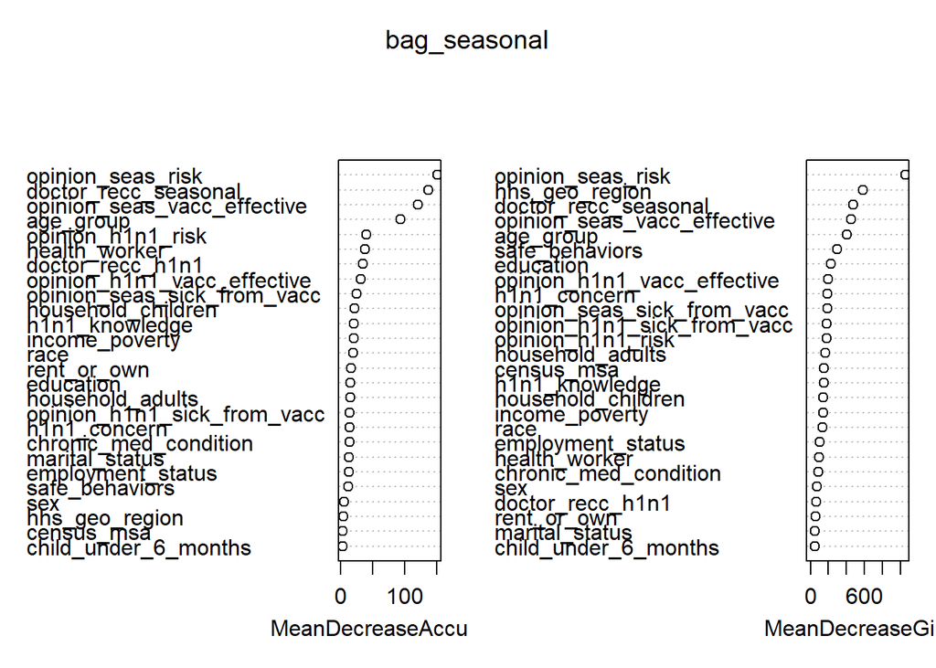

```r
# Important predictors from Bagging for seasonal flu
varImpPlot(bag_seasonal)
```

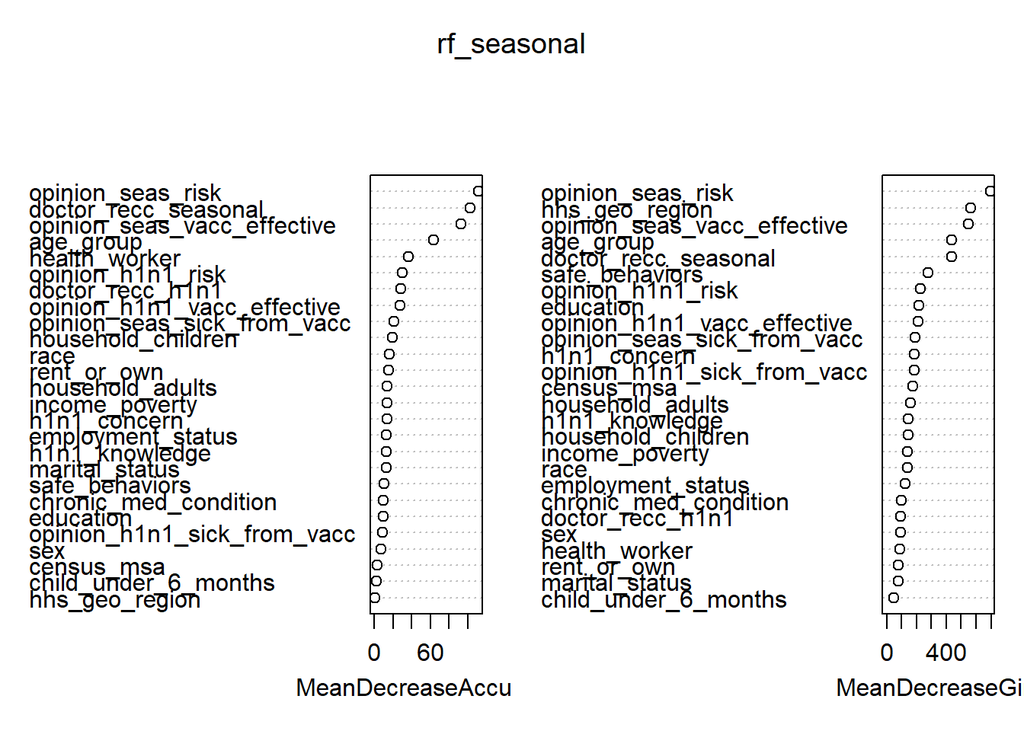

```r
# Important predictors from Random Forest for seasonal flu
varImpPlot(rf_seasonal)
```

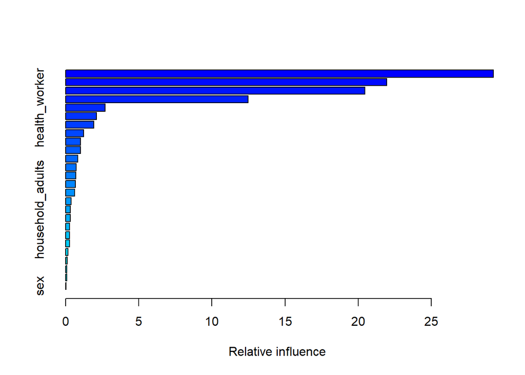

```
##                                                     var rel.inf
## opinion_seas_risk                     opinion_seas_risk 29.2361
## opinion_seas_vacc_effective opinion_seas_vacc_effective 21.9530
## doctor_recc_seasonal               doctor_recc_seasonal 20.4686
## age_group                                     age_group 12.4743
## health_worker                             health_worker  2.6876
## hhs_geo_region                           hhs_geo_region  2.1242
## opinion_seas_sick_from_vacc opinion_seas_sick_from_vacc  1.9336
## h1n1_knowledge                           h1n1_knowledge  1.2402
## race                                               race  1.0164
## education                                     education  1.0109
## rent_or_own                                 rent_or_own  0.8407
## income_poverty                           income_poverty  0.7106
## safe_behaviors                           safe_behaviors  0.6930
## opinion_h1n1_sick_from_vacc opinion_h1n1_sick_from_vacc  0.6661
## opinion_h1n1_risk                     opinion_h1n1_risk  0.6157
## chronic_med_condition             chronic_med_condition  0.3886
## household_adults                       household_adults  0.3247
## employment_status                     employment_status  0.3207
## opinion_h1n1_vacc_effective opinion_h1n1_vacc_effective  0.2803
## doctor_recc_h1n1                       doctor_recc_h1n1  0.2781
## census_msa                                   census_msa  0.2630
## h1n1_concern                               h1n1_concern  0.1683
## household_children                   household_children  0.1093
## child_under_6_months               child_under_6_months  0.0899
## marital_status                           marital_status  0.0698
## sex                                                 sex  0.0361
```

```r
# Important predictors from GBM for seasonal flu
summary(boost_seasonal)
```

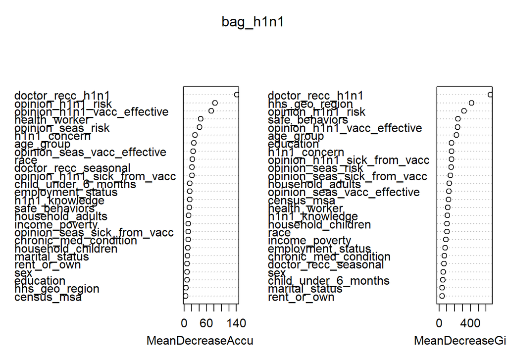

```r
# Important predictors from Bagging for h1n1 flu
varImpPlot(bag_h1n1)
```

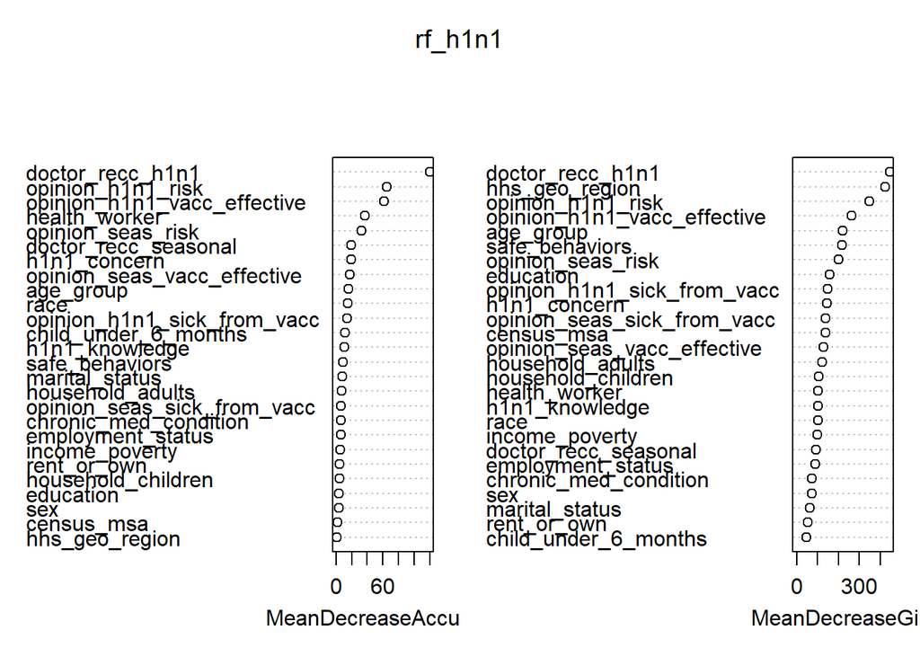

```r
# Important predictors from Random Forest for h1n1 flu
varImpPlot(rf_h1n1)
```

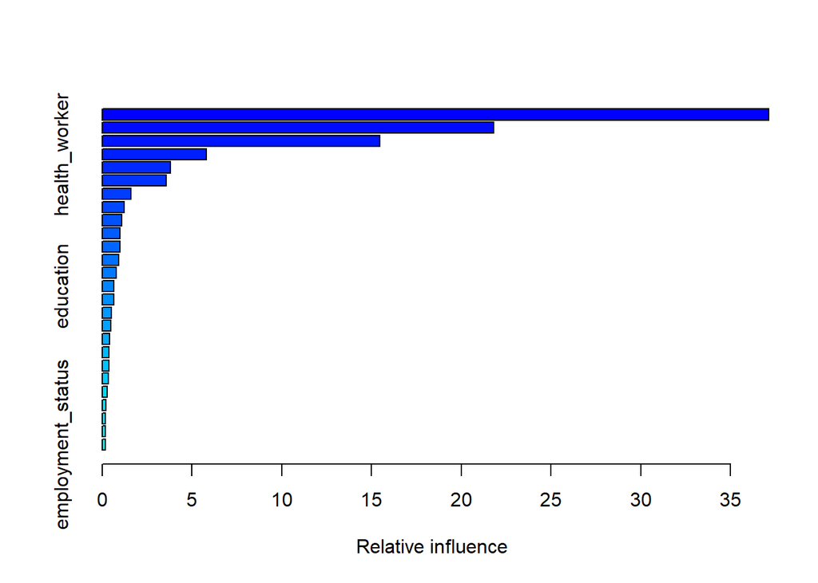

```
##                                                     var rel.inf
## doctor_recc_h1n1                       doctor_recc_h1n1  37.134
## opinion_h1n1_risk                     opinion_h1n1_risk  21.809
## opinion_h1n1_vacc_effective opinion_h1n1_vacc_effective  15.483
## health_worker                             health_worker   5.802
## hhs_geo_region                           hhs_geo_region   3.796
## opinion_seas_risk                     opinion_seas_risk   3.559
## age_group                                     age_group   1.598
## doctor_recc_seasonal               doctor_recc_seasonal   1.214
## h1n1_knowledge                           h1n1_knowledge   1.087
## opinion_seas_sick_from_vacc opinion_seas_sick_from_vacc   1.003
## safe_behaviors                           safe_behaviors   0.977
## race                                               race   0.927
## opinion_h1n1_sick_from_vacc opinion_h1n1_sick_from_vacc   0.801
## education                                     education   0.665
## opinion_seas_vacc_effective opinion_seas_vacc_effective   0.644
## h1n1_concern                               h1n1_concern   0.497
## child_under_6_months               child_under_6_months   0.490
## marital_status                           marital_status   0.412
## income_poverty                           income_poverty   0.388
## chronic_med_condition             chronic_med_condition   0.368
## household_adults                       household_adults   0.341
## household_children                   household_children   0.277
## sex                                                 sex   0.224
## rent_or_own                                 rent_or_own   0.174
## census_msa                                   census_msa   0.172
## employment_status                     employment_status   0.158
```

```r
# Important predictors from GBM for h1n1 flu
summary(boost_h1n1)
```

## Exploratory models

### Full GLM with interactions

```r
# Fit logistic reg on full data
Full_glm <-
  glm(seasonal_vaccine~.*doctor_recc_seasonal*age_group,
      data = seasonal_train, family = binomial)
#summary(Full_glm)
#length(coef(Full_glm))-1
```

### Full logistic regression model with interactions - Training error

```r
# Get the number of rows
n_train <- nrow(seasonal_train)

# Store the predictions on the existing data
glm.probs <- predict(Full_glm, type = 'response')

# Determine predictions
glm.pred <- rep(0, n_train)
glm.pred[glm.probs > .5] <- 1

# Generate confusion matrix
table(glm.pred, seasonal_train$seasonal_vaccine)
```

```
##
## glm.pred    0    1
##        0 4999 1262
##        1 1154 4371
```

```r
# Proportion of correct responses
mean(glm.pred == seasonal_train$seasonal_vaccine)
```

```
## [1] 0.795
```

Training accuracy of 79.5, compared to 78.7% for the full logistic model without interactions. But the test accuracy decreases.

### Full logistic regression model with interactions - Test error

```r
# Get the number of rows
n_test <- nrow(seasonal_test)

# Store the predictions on the existing data
glm.probs <- predict(Full_glm, newdata = seasonal_test,type = 'response')

# Determine predictions
glm.pred <- rep(0, n_test)
glm.pred[glm.probs > .5] <- 1

# Generate confusion matrix
table(glm.pred, seasonal_test$seasonal_vaccine)
```

```
##
## glm.pred    0    1
##        0 3275  948
##        1  826 2807
```

```r
# Proportion of correct responses
mean(glm.pred == seasonal_test$seasonal_vaccine)
```

```
## [1] 0.774
```

Applied to the testing set, the testing accuracy dips slightly to 77.4% from 77.8% after adding interactions. The naive model would have done 52.2%.

### Lasso with interactions

```r
# Reference: http://www.sthda.com/english/articles/36-classification-methods-essentials/149-penalized-logistic-regression-essentials-in-r-ridge-lasso-and-elastic-net/

set.seed(14)

x <- model.matrix(seasonal_vaccine~.*doctor_recc_seasonal*age_group, seasonal_train)[,-1]
y <- seasonal_train$seasonal_vaccine


cv.lasso <- cv.glmnet(x, y, alpha = 1, family = "binomial", nfolds = 5)

lasso_model <- glmnet(x, y, alpha = 1, family = "binomial",
                lambda = cv.lasso$lambda.min)

#coef(lasso_model)
```

### Lasso with interactions - Training errors

```r
# Store the predictions on the existing data
lasso_train_probs <- predict(lasso_model, newx = x, type = 'response')

# Determine predictions
lasso_train_pred <- ifelse(lasso_train_probs > 0.5, 1, 0)

# Generate confusion matrix
table(lasso_train_pred, seasonal_train$seasonal_vaccine)
```

```
##
## lasso_train_pred    0    1
##                0 5017 1350
##                1 1136 4283
```

```r
mean(lasso_train_pred == seasonal_train$seasonal_vaccine)
```

```
## [1] 0.789
```

Training accuracy - 78.9%. Note that including doctor recommendation and age group interactions did increase training accuracy to 0.789, but test accuracy were decreased.

### Lasso with interactions - Test error

```r
# Make predictions on the test data
x_testing <-
  model.matrix(seasonal_vaccine~.*doctor_recc_seasonal*age_group, seasonal_test)[,-1]
lasso_probs <- predict(lasso_model, newx = x_testing)

lasso_pred <- ifelse(lasso_probs > 0.5, 1, 0)

# Generate confusion matrix
table(lasso_pred, seasonal_test$seasonal_vaccine)
```

```
##
## lasso_pred    0    1
##          0 3630 1413
##          1  471 2342
```

```r
# Accuracy
mean(lasso_pred == seasonal_test$seasonal_vaccine)
```

```
## [1] 0.76
```

Including interactions decreased test accuracy to 76% from 76.4%.